# Project: Data Wrangling - "We Rate Dogs"

### Anca Filip - Vodafone

- Introduction
- Gathering Data
- Assessing Data
- Cleaning Data

## Introduction

Based on the Project details, our tasks in this project are: " Data wrangling, which consists of: Gathering data (downloadable file in the Resources tab in the left most panel of your classroom and linked in step 1 below). Assessing data Cleaning data Storing, analyzing, and visualizing your wrangled data Reporting on 1) your data wrangling efforts and 2) your data analyses and visualizations "

In this Notebook I will stop at "storing" the cleaned data; the analysis and reporting will be part of distinct templates.

```python
# import packages
import pandas as pd
import numpy as np
import matplotlib.pyplot as plt
%matplotlib inline
import os
import requests
import json
```

## Gathering Data

We need to use 3 data sources:

1. a .csv that we need to upload into the environment and then import in the notebook.
2. a .tsv that we need to get programatically from a specific link.
3. a dataset retrieved via the tweepy (tweeter API)
1. import the 'twitter-archive-enhanced.csv' file I already loaded in the workspace.

```python
#import the "local" .csv file with enhanced tweets
df_tweet=pd.read_csv('twitter-archive-enhanced.csv')
df_tweet.head(2)
```

|  | tweet_id | in_reply_to_status_id | in_reply_to_user_id | timestamp | source | text | retweeted_status_id | retweeted_status_user_id | retweeted_status_timestamp | expanded_urls | rating_numerator | rating_denominator | name | doggo | floofer | pupper | puppo |
| --- | --- | --- | --- | --- | --- | --- | --- | --- | --- | --- | --- | --- | --- | --- | --- | --- | --- |
| 0 | 892420643555336193 | NaN | NaN | 2017-08-01 16:23:56 +0000 | <a href="http://twitter.com/download/iphone" r... | This is Phineas. He's a mystical boy. Only eve... | NaN | NaN | NaN | https://twitter.com/dog_rates/status/892420643... | 13 | 10 | Phineas | None | None | None | None |
| 1 | 892177421306343426 | NaN | NaN | 2017-08-01 00:17:27 +0000 | <a href="http://twitter.com/download/iphone" r... | This is Tilly. She's just checking pup on you.... | NaN | NaN | NaN | https://twitter.com/dog_rates/status/892177421... | 13 | 10 | Tilly | None | None | None | None |

1. import the 'image-predictions.tsv' file provided through a url using the requests package, method get

```python
#import the web .tsv file with image predictions into the local workspace
url='https://d17h27t6h515a5.cloudfront.net/topher/2017/August/599fd2ad_image-predictions/image-predictions.tsv'
response=requests.get(url)
with open(os.path.join(url.split('/')[-1]), mode='wb') as file:
                      file.write(response.content)
```

```python
#import the .tsv file with image predictions into a df
df_image=pd.read_csv('image-predictions.tsv',sep='\t')
df_image.head(2)
```

|  | tweet_id | jpg_url | img_num | p1 | p1_conf | p1_dog | p2 | p2_conf | p2_dog | p3 | p3_conf | p3_dog |
| --- | --- | --- | --- | --- | --- | --- | --- | --- | --- | --- | --- | --- |
| 0 | 666020888022790149 | https://pbs.twimg.com/media/CT4udn0WwAA0aMy.jpg | 1 | Welsh_springer_spaniel | 0.465074 | True | collie | 0.156665 | True | Shetland_sheepdog | 0.061428 | True |
| 1 | 666029285002620928 | https://pbs.twimg.com/media/CT42GRgUYAA5iDo.jpg | 1 | redbone | 0.506826 | True | miniature_pinscher | 0.074192 | True | Rhodesian_ridgeback | 0.072010 | True |

1. Twitter API: since a. I do not have a twitter account and b. my employer has blocked the access to twitter, I imported the txt. However, bellow is the code needed to retrieve the data via API.

```python
"""
import tweepy
from tweepy import OAuthHandler
import json
from timeit import default_timer as timer

# Query Twitter API for each tweet in the Twitter archive and save JSON in a text file
# These are hidden to comply with Twitter's API terms and conditions
consumer_key = 'HIDDEN'
consumer_secret = 'HIDDEN'
access_token = 'HIDDEN'
access_secret = 'HIDDEN'

auth = OAuthHandler(consumer_key, consumer_secret)
auth.set_access_token(access_token, access_secret)

api = tweepy.API(auth, wait_on_rate_limit=True)

# NOTE TO STUDENT WITH MOBILE VERIFICATION ISSUES:
# df_1 is a DataFrame with the twitter_archive_enhanced.csv file. You may have to
# change line 17 to match the name of your DataFrame with twitter_archive_enhanced.csv
# NOTE TO REVIEWER: this student had mobile verification issues so the following
# Twitter API code was sent to this student from a Udacity instructor
# Tweet IDs for which to gather additional data via Twitter's API
tweet_ids = df_1.tweet_id.values
len(tweet_ids)

# Query Twitter's API for JSON data for each tweet ID in the Twitter archive
count = 0
fails_dict = {}
start = timer()
# Save each tweet's returned JSON as a new line in a .txt file
with open('tweet_json.txt', 'w') as outfile:
    # This loop will likely take 20-30 minutes to run because of Twitter's rate limit
    for tweet_id in tweet_ids:
        count += 1
        print(str(count) + ": " + str(tweet_id))
        try:
            tweet = api.get_status(tweet_id, tweet_mode='extended')
            print("Success")
            json.dump(tweet._json, outfile)
            outfile.write('\n')
        except tweepy.TweepError as e:
            print("Fail")
            fails_dict[tweet_id] = e
            pass
end = timer()
print(end - start)
print(fails_dict)

"""
```

[output not shown]

```python
# Import the txt into our workspace from the link provided

url='https://video.udacity-data.com/topher/2018/November/5be5fb7d_tweet-json/tweet-json.txt'
response=requests.get(url)
with open(os.path.join(url.split('/')[-1]), mode='wb') as file:
                      file.write(response.content)
```

```python
# parse the json data from txt to a list of objects

json_data=[]
with open('tweet-json.txt', encoding='utf-8') as json_file:
     for line in json_file:
        json_data.append(json.loads(line))
```

```python
# convert the json data to a df

df_api=pd.DataFrame(json_data)
df_api.head(2)
```

|  | contributors | coordinates | created_at | display_text_range | entities | extended_entities | favorite_count | favorited | full_text | geo | ... | possibly_sensitive_appealable | quoted_status | quoted_status_id | quoted_status_id_str | retweet_count | retweeted | retweeted_status | source | truncated | user |
| --- | --- | --- | --- | --- | --- | --- | --- | --- | --- | --- | --- | --- | --- | --- | --- | --- | --- | --- | --- | --- | --- |
| 0 | None | None | Tue Aug 01 16:23:56 +0000 2017 | [0, 85] | {'hashtags': [], 'symbols': [], 'user_mentions... | {'media': [{'id': 892420639486877696, 'id_str'... | 39467 | False | This is Phineas. He's a mystical boy. Only eve... | None | ... | False | NaN | NaN | NaN | 8853 | False | NaN | <a href="http://twitter.com/download/iphone" r... | False | {'id': 4196983835, 'id_str': '4196983835', 'na... |
| 1 | None | None | Tue Aug 01 00:17:27 +0000 2017 | [0, 138] | {'hashtags': [], 'symbols': [], 'user_mentions... | {'media': [{'id': 892177413194625024, 'id_str'... | 33819 | False | This is Tilly. She's just checking pup on you.... | None | ... | False | NaN | NaN | NaN | 6514 | False | NaN | <a href="http://twitter.com/download/iphone" r... | False | {'id': 4196983835, 'id_str': '4196983835', 'na... |

2 rows × 31 columns

### Assessing Data

I intend to first check the overall structure of the dataframes (info/describe) to identify missing data, no of rows/columns, columns that are common betwen the datasets, odd data types; Then, I will get into more details with specific variables that I will find usefull for analysis.

First, let's check the overall structures:

```python
df_tweet.info()
```

```
<class 'pandas.core.frame.DataFrame'>
RangeIndex: 2356 entries, 0 to 2355
Data columns (total 17 columns):
tweet_id                      2356 non-null int64
in_reply_to_status_id         78 non-null float64
in_reply_to_user_id           78 non-null float64
timestamp                     2356 non-null object
source                        2356 non-null object
text                          2356 non-null object
retweeted_status_id           181 non-null float64
retweeted_status_user_id      181 non-null float64
retweeted_status_timestamp    181 non-null object
expanded_urls                 2297 non-null object
rating_numerator              2356 non-null int64
rating_denominator            2356 non-null int64
name                          2356 non-null object
doggo                         2356 non-null object
floofer                       2356 non-null object
pupper                        2356 non-null object
puppo                         2356 non-null object
dtypes: float64(4), int64(3), object(10)
memory usage: 313.0+ KB
```

a1 **df_tweet**

> Quality issues:
> > - in_reply_to_user_id / status; retweeted_status_id/user_id/timestamp missing data : Probably because all other posts are originals.
> > - expanded_urls missing data
> > - timestamp and retweeted_status_timestamp texts instead of datetime
> > - user_id, tweet_id, etc - all numbers int or float

```python
df_tweet.describe()
```

|  | tweet_id | in_reply_to_status_id | in_reply_to_user_id | retweeted_status_id | retweeted_status_user_id | rating_numerator | rating_denominator |
| --- | --- | --- | --- | --- | --- | --- | --- |
| count | 2.356000e+03 | 7.800000e+01 | 7.800000e+01 | 1.810000e+02 | 1.810000e+02 | 2356.000000 | 2356.000000 |
| mean | 7.427716e+17 | 7.455079e+17 | 2.014171e+16 | 7.720400e+17 | 1.241698e+16 | 13.126486 | 10.455433 |
| std | 6.856705e+16 | 7.582492e+16 | 1.252797e+17 | 6.236928e+16 | 9.599254e+16 | 45.876648 | 6.745237 |
| min | 6.660209e+17 | 6.658147e+17 | 1.185634e+07 | 6.661041e+17 | 7.832140e+05 | 0.000000 | 0.000000 |
| 25% | 6.783989e+17 | 6.757419e+17 | 3.086374e+08 | 7.186315e+17 | 4.196984e+09 | 10.000000 | 10.000000 |
| 50% | 7.196279e+17 | 7.038708e+17 | 4.196984e+09 | 7.804657e+17 | 4.196984e+09 | 11.000000 | 10.000000 |
| 75% | 7.993373e+17 | 8.257804e+17 | 4.196984e+09 | 8.203146e+17 | 4.196984e+09 | 12.000000 | 10.000000 |
| max | 8.924206e+17 | 8.862664e+17 | 8.405479e+17 | 8.874740e+17 | 7.874618e+17 | 1776.000000 | 170.000000 |

a2 **df_tweet**

> Quality issues:
> > - odd max rating_nominator and rating_denominator

```python
df_tweet.sample(7)
```

|  | tweet_id | in_reply_to_status_id | in_reply_to_user_id | timestamp | source | text | retweeted_status_id | retweeted_status_user_id | retweeted_status_timestamp | expanded_urls | rating_numerator | rating_denominator | name | doggo | floofer | pupper | puppo |
| --- | --- | --- | --- | --- | --- | --- | --- | --- | --- | --- | --- | --- | --- | --- | --- | --- | --- |
| 696 | 786664955043049472 | NaN | NaN | 2016-10-13 20:28:35 +0000 | <a href="http://twitter.com/download/iphone" r... | "Honestly Kathleen I just want more Ken Bone" ... | NaN | NaN | NaN | https://twitter.com/dog_rates/status/786664955... | 12 | 10 | None | None | None | None | None |
| 1764 | 678424312106393600 | NaN | NaN | 2015-12-20 03:58:55 +0000 | <a href="http://twitter.com/download/iphone" r... | This is Crystal. She's a shitty fireman. No se... | NaN | NaN | NaN | https://twitter.com/dog_rates/status/678424312... | 2 | 10 | Crystal | None | None | None | None |
| 564 | 802323869084381190 | NaN | NaN | 2016-11-26 01:31:31 +0000 | <a href="http://twitter.com/download/iphone" r... | This is Severus. He's here to fix your cable. ... | NaN | NaN | NaN | https://twitter.com/dog_rates/status/802323869... | 13 | 10 | Severus | None | None | None | None |
| 2139 | 670037189829525505 | NaN | NaN | 2015-11-27 00:31:29 +0000 | <a href="http://twitter.com/download/iphone" r... | Awesome dog here. Not sure where it is tho. Sp... | NaN | NaN | NaN | https://twitter.com/dog_rates/status/670037189... | 5 | 10 | None | None | None | None | None |
| 2271 | 667495797102141441 | NaN | NaN | 2015-11-20 00:12:54 +0000 | <a href="http://twitter.com" rel="nofollow">Tw... | This is Philippe from Soviet Russia. Commandin... | NaN | NaN | NaN | https://twitter.com/dog_rates/status/667495797... | 9 | 10 | Philippe | None | None | None | None |
| 1980 | 672975131468300288 | NaN | NaN | 2015-12-05 03:05:49 +0000 | <a href="http://twitter.com/download/iphone" r... | This is Chuckles. He is one skeptical pupper. ... | NaN | NaN | NaN | https://twitter.com/dog_rates/status/672975131... | 10 | 10 | Chuckles | None | None | pupper | None |
| 765 | 777885040357281792 | NaN | NaN | 2016-09-19 15:00:20 +0000 | <a href="http://twitter.com/download/iphone" r... | This is Wesley. He's clearly trespassing. Seem... | NaN | NaN | NaN | https://twitter.com/dog_rates/status/777885040... | 3 | 10 | Wesley | None | None | None | None |

I see there are rows with none on all doggo/etc columns. Let's see how many rows are like this:

```python
# count rows with no dog type flag
df_tweet[(df_tweet['doggo']=='None') &  (df_tweet['floofer']=='None') &\
         (df_tweet['pupper']=='None') & (df_tweet['puppo']=='None')]['tweet_id'].count()
```

```
1976
```

a3 **df_tweet**

> Quality issues:
> > - doggo, floofer, pupper, puppo are texts instead of 0/1, true/false or NAN; impossible to see where there are missing values from the .info()
> > - doggo, floofer, pupper, puppo do not cover all records - 1976 all have "none" on all 4 categories

> Tidiness issues:
> > - doggo, floofer, pupper, puppo maybe should be a single column.

```python
# check the odd numerators
df_tweet['rating_numerator'].value_counts().sort_index()
```

```
0         2
1         9
2         9
3        19
4        17
5        37
6        32
7        55
8       102
9       158
10      461
11      464
12      558
13      351
14       54
```

[output cut: 26 more lines]

So there are some records with odd numerators; could be a data aquiring error or something quirky in that tweet. Let's look at the records with 0 and more than 14 as numerator.

```python
# 'force' the notebook to show the max of the text in the tweet
pd.set_option('display.max_colwidth', 0)

# select the tweets with 0 or >14 numerator

df_tweet[(df_tweet['rating_numerator']==0) | (df_tweet['rating_numerator']>14)][['tweet_id', 'text','rating_numerator','rating_denominator' ]]
```

|  | tweet_id | text | rating_numerator | rating_denominator |
| --- | --- | --- | --- | --- |
| 55 | 881633300179243008 | @roushfenway These are good dogs but 17/10 is an emotional impulse rating. More like 13/10s | 17 | 10 |
| 188 | 855862651834028034 | @dhmontgomery We also gave snoop dogg a 420/10 but I think that predated your research | 420 | 10 |
| 189 | 855860136149123072 | @s8n You tried very hard to portray this good boy as not so good, but you have ultimately failed. His goodness shines through. 666/10 | 666 | 10 |
| 285 | 838916489579200512 | RT @KibaDva: I collected all the good dogs!! 15/10 @dog_rates #GoodDogs https://t.co/6UCGFczlOI | 15 | 10 |
| 290 | 838150277551247360 | @markhoppus 182/10 | 182 | 10 |
| 291 | 838085839343206401 | @bragg6of8 @Andy_Pace_ we are still looking for the first 15/10 | 15 | 10 |
| 313 | 835246439529840640 | @jonnysun @Lin_Manuel ok jomny I know you're excited but 960/00 isn't a valid rating, 13/10 is tho | 960 | 0 |
| 315 | 835152434251116546 | When you're so blinded by your systematic plagiarism that you forget what day it is. 0/10 https://t.co/YbEJPkg4Ag | 0 | 10 |
| 340 | 832215909146226688 | RT @dog_rates: This is Logan, the Chow who lived. He solemnly swears he's up to lots of good. H*ckin magical af 9.75/10 https://t.co/yBO5wu… | 75 | 10 |
| 433 | 820690176645140481 | The floofs have been released I repeat the floofs have been released. 84/70 https://t.co/NIYC820tmd | 84 | 70 |
| 516 | 810984652412424192 | Meet Sam. She smiles 24/7 &amp; secretly aspires to be a reindeer. \nKeep Sam smiling by clicking and sharing this link:\nhttps://t.co/98tB8y7y7t https://t.co/LouL5vdvxx | 24 | 7 |
| 695 | 786709082849828864 | This is Logan, the Chow who lived. He solemnly swears he's up to lots of good. H*ckin magical af 9.75/10 https://t.co/yBO5wuqaPS | 75 | 10 |
| 763 | 778027034220126208 | This is Sophie. She's a Jubilant Bush Pupper. Super h*ckin rare. Appears at random just to smile at the locals. 11.27/10 would smile back https://t.co/QFaUiIHxHq | 27 | 10 |
| 902 | 758467244762497024 | Why does this never happen at my front door... 165/150 https://t.co/HmwrdfEfUE | 165 | 150 |
| 979 | 749981277374128128 | This is Atticus. He's quite simply America af. 1776/10 https://t.co/GRXwMxLBkh | 1776 | 10 |
| 1016 | 746906459439529985 | PUPDATE: can't see any. Even if I could, I couldn't reach them to pet. 0/10 much disappointment https://t.co/c7WXaB2nqX | 0 | 10 |
| 1120 | 731156023742988288 | Say hello to this unbelievably well behaved squad of doggos. 204/170 would try to pet all at once https://t.co/yGQI3He3xv | 204 | 170 |
| 1202 | 716439118184652801 | This is Bluebert. He just saw that both #FinalFur match ups are split 50/50. Amazed af. 11/10 https://t.co/Kky1DPG4iq | 50 | 50 |
| 1228 | 713900603437621249 | Happy Saturday here's 9 puppers on a bench. 99/90 good work everybody https://t.co/mpvaVxKmc1 | 99 | 90 |
| 1254 | 710658690886586372 | Here's a brigade of puppers. All look very prepared for whatever happens next. 80/80 https://t.co/0eb7R1Om12 | 80 | 80 |
| 1274 | 709198395643068416 | From left to right:\nCletus, Jerome, Alejandro, Burp, &amp; Titson\nNone know where camera is. 45/50 would hug all at once https://t.co/sedre1ivTK | 45 | 50 |
| 1351 | 704054845121142784 | Here is a whole flock of puppers. 60/50 I'll take the lot https://t.co/9dpcw6MdWa | 60 | 50 |
| 1433 | 697463031882764288 | Happy Wednesday here's a bucket of pups. 44/40 would pet all at once https://t.co/HppvrYuamZ | 44 | 40 |
| 1634 | 684225744407494656 | Two sneaky puppers were not initially seen, moving the rating to 143/130. Please forgive us. Thank you https://t.co/kRK51Y5ac3 | 143 | 130 |
| 1635 | 684222868335505415 | Someone help the girl is being mugged. Several are distracting her while two steal her shoes. Clever puppers 121/110 https://t.co/1zfnTJLt55 | 121 | 110 |
| 1663 | 682808988178739200 | I'm aware that I could've said 20/16, but here at WeRateDogs we are very professional. An inconsistent rating scale is simply irresponsible | 20 | 16 |
| 1712 | 680494726643068929 | Here we have uncovered an entire battalion of holiday puppers. Average of 11.26/10 https://t.co/eNm2S6p9BD | 26 | 10 |
| 1779 | 677716515794329600 | IT'S PUPPERGEDDON. Total of 144/120 ...I think https://t.co/ZanVtAtvIq | 144 | 120 |
| 1843 | 675853064436391936 | Here we have an entire platoon of puppers. Total score: 88/80 would pet all at once https://t.co/y93p6FLvVw | 88 | 80 |
| 2074 | 670842764863651840 | After so many requests... here you go.\n\nGood dogg. 420/10 https://t.co/yfAAo1gdeY | 420 | 10 |

OK, so there are some errors but some are actually pictures with many dogs.

a4 **df_tweet**

> Quality issues:

> > errors in the rating: (index=corect score): (313=13/10, 340=9.75/10, 763=11.27/10, 1202 = 11/10, 1712 = 11.26/10)

I saw some texts that looked the same. Let's check for duplicates now.

```python
# Let's count how many duplicates are, first overall in the records and then just on the tweet_id column:
df_tweet.duplicated()[df_tweet.duplicated()==True].count(), \
df_tweet['tweet_id'].duplicated()[df_tweet['tweet_id'].duplicated()==True].count()
```

```
(0, 0)
```

Hm... but for sure I saw one, index 340 and 695 reffer to the same dog. So the duplicates are generated by the retweets. For instance here, the RT has a retweeted status.

```python
df_tweet[df_tweet['tweet_id']==832215909146226688]
```

|  | tweet_id | in_reply_to_status_id | in_reply_to_user_id | timestamp | source | text | retweeted_status_id | retweeted_status_user_id | retweeted_status_timestamp | expanded_urls | rating_numerator | rating_denominator | name | doggo | floofer | pupper | puppo |
| --- | --- | --- | --- | --- | --- | --- | --- | --- | --- | --- | --- | --- | --- | --- | --- | --- | --- |
| 340 | 832215909146226688 | NaN | NaN | 2017-02-16 13:11:49 +0000 | <a href="http://twitter.com/download/iphone" rel="nofollow">Twitter for iPhone</a> | RT @dog_rates: This is Logan, the Chow who lived. He solemnly swears he's up to lots of good. H*ckin magical af 9.75/10 https://t.co/yBO5wu… | 7.867091e+17 | 4.196984e+09 | 2016-10-13 23:23:56 +0000 | https://twitter.com/dog_rates/status/786709082849828864/photo/1 | 75 | 10 | Logan | None | None | None | None |

Moving forwards, there are also some denominators different than the classical 10.

```python
df_tweet['rating_denominator'].value_counts().sort_index()
```

```
0      1
2      1
7      1
10     2333
11     3
15     1
16     1
20     2
40     1
50     3
70     1
80     2
90     1
110    1
120    1
130    1
150    1
170    1
Name: rating_denominator, dtype: int64
```

Let's also look at the specific records, with the exception of the ones we already spotted when we checked the numerators.

```python
df_tweet[((df_tweet['rating_denominator']<10) | (df_tweet['rating_denominator']>10))\
        & ((df_tweet['rating_numerator']>0) & (df_tweet['rating_numerator']<=14))]\
                                              [['tweet_id', 'text','rating_numerator','rating_denominator' ]]
```

|  | tweet_id | text | rating_numerator | rating_denominator |
| --- | --- | --- | --- | --- |
| 342 | 832088576586297345 | @docmisterio account started on 11/15/15 | 11 | 15 |
| 784 | 775096608509886464 | RT @dog_rates: After so many requests, this is Bretagne. She was the last surviving 9/11 search dog, and our second ever 14/10. RIP https:/… | 9 | 11 |
| 1068 | 740373189193256964 | After so many requests, this is Bretagne. She was the last surviving 9/11 search dog, and our second ever 14/10. RIP https://t.co/XAVDNDaVgQ | 9 | 11 |
| 1165 | 722974582966214656 | Happy 4/20 from the squad! 13/10 for all https://t.co/eV1diwds8a | 4 | 20 |
| 1598 | 686035780142297088 | Yes I do realize a rating of 4/20 would've been fitting. However, it would be unjust to give these cooperative pups that low of a rating | 4 | 20 |
| 1662 | 682962037429899265 | This is Darrel. He just robbed a 7/11 and is in a high speed police chase. Was just spotted by the helicopter 10/10 https://t.co/7EsP8LmSp5 | 7 | 11 |
| 2335 | 666287406224695296 | This is an Albanian 3 1/2 legged Episcopalian. Loves well-polished hardwood flooring. Penis on the collar. 9/10 https://t.co/d9NcXFKwLv | 1 | 2 |

a5 **df_tweet**

> Quality issues:

> > errors in the rating: (index=corect score): (1068=14/10, 1165=13/10, 1662=10/10, 2335=9/10)

> Analysis comments:
> > - some records might not actually be dog ratings, indexes: 342, 1598

```python
# check the names - see if we have valid data
df_tweet['name'].value_counts()
```

```
None         745
a            55
Charlie      12
Cooper       11
Oliver       11
Lucy         11
Lola         10
Penny        10
Tucker       10
Winston      9
Bo           9
Sadie        8
the          8
Toby         7
an           7
Buddy        7
Daisy        7
Bailey       7
Jax          6
Koda         6
Dave         6
Milo         6
Scout        6
Leo          6
Rusty        6
Jack         6
Stanley      6
Bella        6
Oscar        6
Sunny        5
            ..
Mimosa       1
Berb         1
Evy          1
Blakely      1
Hazel        1
Kollin       1
Luther       1
Herb         1
Spanky       1
Filup        1
Beebop       1
Kara         1
Clarq        1
Chef         1
Ginger       1
Arlo         1
Cuddles      1
such         1
Humphrey     1
light        1
Kathmandu    1
Odin         1
Gunner       1
Damon        1
Jarvis       1
Mary         1
Chesney      1
Obi          1
Katie        1
Spencer      1
Name: name, Length: 957, dtype: int64
```

There are some names that are probably errors from the programatic extraction. Let's list all names and check visually all non-names.

```python
df_tweet['name'].unique()
```

```
array(['Phineas', 'Tilly', 'Archie', 'Darla', 'Franklin', 'None', 'Jax',
       'Zoey', 'Cassie', 'Koda', 'Bruno', 'Ted', 'Stuart', 'Oliver', 'Jim',
       'Zeke', 'Ralphus', 'Canela', 'Gerald', 'Jeffrey', 'such', 'Maya',
       'Mingus', 'Derek', 'Roscoe', 'Waffles', 'Jimbo', 'Maisey', 'Lilly',
       'Earl', 'Lola', 'Kevin', 'Yogi', 'Noah', 'Bella', 'Grizzwald',
       'Rusty', 'Gus', 'Stanley', 'Alfy', 'Koko', 'Rey', 'Gary', 'a',
       'Elliot', 'Louis', 'Jesse', 'Romeo', 'Bailey', 'Duddles', 'Jack',
       'Emmy', 'Steven', 'Beau', 'Snoopy', 'Shadow', 'Terrance', 'Aja',
       'Penny', 'Dante', 'Nelly', 'Ginger', 'Benedict', 'Venti', 'Goose',
       'Nugget', 'Cash', 'Coco', 'Jed', 'Sebastian', 'Walter', 'Sierra',
       'Monkey', 'Harry', 'Kody', 'Lassie', 'Rover', 'Napolean', 'Dawn',
       'Boomer', 'Cody', 'Rumble', 'Clifford', 'quite', 'Dewey', 'Scout',
       'Gizmo', 'Cooper', 'Harold', 'Shikha', 'Jamesy', 'Lili', 'Sammy',
       'Meatball', 'Paisley', 'Albus', 'Neptune', 'Quinn', 'Belle',
       'Zooey', 'Dave', 'Jersey', 'Hobbes', 'Burt', 'Lorenzo', 'Carl',
       'Jordy', 'Milky', 'Trooper', 'Winston', 'Sophie', 'Wyatt', 'Rosie',
       'Thor', 'Oscar', 'Luna', 'Callie', 'Cermet', 'George', 'Marlee',
       'Arya', 'Einstein', 'Alice', 'Rumpole', 'Benny', 'Aspen', 'Jarod',
       'Wiggles', 'General', 'Sailor', 'Astrid', 'Iggy', 'Snoop', 'Kyle',
       'Leo', 'Riley', 'Gidget', 'Noosh', 'Odin', 'Jerry', 'Charlie',
       'Georgie', 'Rontu', 'Cannon', 'Furzey', 'Daisy', 'Tuck', 'Barney',
       'Vixen', 'Jarvis', 'Mimosa', 'Pickles', 'Bungalo', 'Brady', 'Margo',
       'Sadie', 'Hank', 'Tycho', 'Stephan', 'Indie', 'Winnie', 'Bentley',
       'Ken', 'Max', 'Maddie', 'Pipsy', 'Monty', 'Sojourner', 'Odie',
       'Arlo', 'Sunny', 'Vincent', 'Lucy', 'Clark', 'Mookie', 'Meera',
       'Buddy', 'Ava', 'Rory', 'Eli', 'Ash', 'Tucker', 'Tobi', 'Chester',
       'Wilson', 'Sunshine', 'Lipton', 'Gabby', 'Bronte', 'Poppy', 'Rhino',
       'Willow', 'not', 'Orion', 'Eevee', 'Smiley', 'Logan', 'Moreton',
       'Klein', 'Miguel', 'Emanuel', 'Kuyu', 'Dutch', 'Pete', 'Scooter',
       'Reggie', 'Kyro', 'Samson', 'Loki', 'Mia', 'Malcolm', 'Dexter',
       'Alfie', 'Fiona', 'one', 'Mutt', 'Bear', 'Doobert', 'Beebop',
       'Alexander', 'Sailer', 'Brutus', 'Kona', 'Boots', 'Ralphie', 'Phil',
       'Cupid', 'Pawnd', 'Pilot', 'Ike', 'Mo', 'Toby', 'Sweet', 'Pablo',
       'Nala', 'Balto', 'Crawford', 'Gabe', 'Mattie', 'Jimison',
       'Hercules', 'Duchess', 'Harlso', 'Sampson', 'Sundance', 'Luca',
       'Flash', 'Finn', 'Peaches', 'Howie', 'Jazzy', 'Anna', 'Bo',
       'Seamus', 'Wafer', 'Chelsea', 'Tom', 'Moose', 'Florence', 'Autumn',
       'Dido', 'Eugene', 'Herschel', 'Strudel', 'Tebow', 'Chloe', 'Betty',
       'Timber', 'Binky', 'Dudley', 'Comet', 'Larry', 'Levi', 'Akumi',
       'Titan', 'Olivia', 'Alf', 'Oshie', 'Bruce', 'Chubbs', 'Sky',
```

[output cut: 85 more lines]

```
       'Julius', 'Tanner', 'Sparky', 'Anthony', 'Holly', 'Jett', 'Amy',
       'Sage', 'Andy', 'Mason', 'Trigger', 'Antony', 'Creg', 'Traviss',
       'Gin', 'Jeffrie', 'Danny', 'Ester', 'Pluto', 'Bloo', 'Edd', 'Willy',
       'Herb', 'Damon', 'Peanut', 'Nigel', 'Butters', 'Sandra', 'Fabio',
       'Randall', 'Liam', 'Tommy', 'Ben', 'Raphael', 'Julio', 'Andru',
       'Kloey', 'Shawwn', 'Skye', 'Kollin', 'Ronduh', 'Billl', 'Saydee',
       'Dug', 'Tessa', 'Sully', 'Kirk', 'Ralf', 'Clarq', 'Jaspers',
       'Samsom', 'Harrison', 'Chaz', 'Jeremy', 'Jaycob', 'Lambeau',
       'Ruffles', 'Amélie', 'Bobb', 'Banditt', 'Kevon', 'Winifred', 'Hanz',
       'Churlie', 'Zeek', 'Timofy', 'Maks', 'Jomathan', 'Kallie', 'Marvin',
       'Spark', 'Gòrdón', 'Jo', 'DayZ', 'Jareld', 'Torque', 'Ron',
       'Skittles', 'Cleopatricia', 'Erik', 'Stu', 'Tedrick', 'Filup',
       'Kial', 'Naphaniel', 'Dook', 'Hall', 'Philippe', 'Biden', 'Fwed',
       'Genevieve', 'Joshwa', 'Bradlay', 'Clybe', 'Keet', 'Carll',
       'Jockson', 'Josep', 'Lugan', 'Christoper'], dtype=object)
```

a6 **df_tweet**

> Quality issues:
> > - missing names: 745 None
> > - wrong names: 'such', 'a', 'quite', 'not', 'one','incredibly', 'mad', 'an', 'very', 'O', 'just','my', 'his', 'this', 'unacceptable','actually','getting', 'all', 'old', 'infuriating','the','officially', 'life','light', 'space','by',

Let's take a look at the **images df**:

```python
df_image.info()
```

```
<class 'pandas.core.frame.DataFrame'>
RangeIndex: 2075 entries, 0 to 2074
Data columns (total 12 columns):
tweet_id    2075 non-null int64
jpg_url     2075 non-null object
img_num     2075 non-null int64
p1          2075 non-null object
p1_conf     2075 non-null float64
p1_dog      2075 non-null bool
p2          2075 non-null object
p2_conf     2075 non-null float64
p2_dog      2075 non-null bool
p3          2075 non-null object
p3_conf     2075 non-null float64
p3_dog      2075 non-null bool
dtypes: bool(3), float64(3), int64(2), object(4)
memory usage: 152.1+ KB
```

```python
df_image.describe()
```

|  | tweet_id | img_num | p1_conf | p2_conf | p3_conf |
| --- | --- | --- | --- | --- | --- |
| count | 2.075000e+03 | 2075.000000 | 2075.000000 | 2.075000e+03 | 2.075000e+03 |
| mean | 7.384514e+17 | 1.203855 | 0.594548 | 1.345886e-01 | 6.032417e-02 |
| std | 6.785203e+16 | 0.561875 | 0.271174 | 1.006657e-01 | 5.090593e-02 |
| min | 6.660209e+17 | 1.000000 | 0.044333 | 1.011300e-08 | 1.740170e-10 |
| 25% | 6.764835e+17 | 1.000000 | 0.364412 | 5.388625e-02 | 1.622240e-02 |
| 50% | 7.119988e+17 | 1.000000 | 0.588230 | 1.181810e-01 | 4.944380e-02 |
| 75% | 7.932034e+17 | 1.000000 | 0.843855 | 1.955655e-01 | 9.180755e-02 |
| max | 8.924206e+17 | 4.000000 | 1.000000 | 4.880140e-01 | 2.734190e-01 |

```python
df_image.sample(7)
```

|  | tweet_id | jpg_url | img_num | p1 | p1_conf | p1_dog | p2 | p2_conf | p2_dog | p3 | p3_conf | p3_dog |
| --- | --- | --- | --- | --- | --- | --- | --- | --- | --- | --- | --- | --- |
| 1224 | 744971049620602880 | https://pbs.twimg.com/media/ClarNU8VAAEDrDt.jpg | 1 | toy_poodle | 0.497755 | True | golden_retriever | 0.282017 | True | miniature_poodle | 0.090032 | True |
| 813 | 692535307825213440 | https://pbs.twimg.com/media/CZxhL2yWAAI_DHn.jpg | 1 | pug | 0.413090 | True | French_bulldog | 0.199865 | True | Chihuahua | 0.081991 | True |
| 1209 | 742423170473463808 | https://pbs.twimg.com/media/Ck2d7tJWUAEPTL3.jpg | 1 | pug | 0.997310 | True | Brabancon_griffon | 0.001186 | True | French_bulldog | 0.000428 | True |
| 1531 | 789599242079838210 | https://pbs.twimg.com/media/CvU4UZpXgAE1pAV.jpg | 2 | Chesapeake_Bay_retriever | 0.878822 | True | beagle | 0.018570 | True | Labrador_retriever | 0.017499 | True |
| 849 | 695629776980148225 | https://pbs.twimg.com/media/Cadfl6zWcAEZqIW.jpg | 1 | Old_English_sheepdog | 0.693857 | True | otterhound | 0.232117 | True | West_Highland_white_terrier | 0.012867 | True |
| 626 | 680801747103793152 | https://pbs.twimg.com/media/CXKxkseW8AAjAMY.jpg | 1 | pug | 0.996720 | True | Labrador_retriever | 0.001439 | True | Staffordshire_bullterrier | 0.000518 | True |
| 1835 | 837012587749474308 | https://pbs.twimg.com/media/C52pYJXWgAA2BEf.jpg | 1 | toilet_tissue | 0.186387 | False | cowboy_hat | 0.158555 | False | sombrero | 0.149470 | False |

We have 3 preditions for the race, but I saw some tweets that do not have any dog predictions.

```python
# how many tweets do not have any True dog prediction.

df_image[(df_image['p1_dog']==False) & (df_image['p2_dog']==False) & (df_image['p3_dog']==False)]['tweet_id'].count()
```

```
324
```

```python
# filter the dogs with no dog race predicted
no_race=df_tweet.merge(df_image[(df_image['p1_dog']==False) & (df_image['p2_dog']==False) & (df_image['p3_dog']==False)],on='tweet_id',how='inner')

no_race[['text','p1','p2','p3']]
```

|  | text | p1 | p2 | p3 |
| --- | --- | --- | --- | --- |
| 0 | This is Phineas. He's a mystical boy. Only ever appears in the hole of a donut. 13/10 https://t.co/MgUWQ76dJU | orange | bagel | banana |
| 1 | I've yet to rate a Venezuelan Hover Wiener. This is such an honor. 14/10 paw-inspiring af (IG: roxy.thedoxy) https://t.co/20VrLAA8ba | limousine | tow_truck | shopping_cart |
| 2 | This is Derek. He's late for a dog meeting. 13/10 pet...al to the metal https://t.co/BCoWue0abA | convertible | sports_car | car_wheel |
| 3 | Meet Elliot. He's a Canadian Forrest Pup. Unusual number of antlers for a dog. Sneaky tongue slip to celebrate #Canada150. 12/10 would pet https://t.co/cgwJwowTMC | tusker | Indian_elephant | ibex |
| 4 | This is Louis. He's crossing. It's a big deal. 13/10 h*ckin breathtaking https://t.co/D0wb1GlKAt | street_sign | umbrella | traffic_light |
| 5 | This is Steven. He has trouble relating to other dogs. Quite shy. Neck longer than average. Tropical probably. 11/10 would still pet https://t.co/2mJCDEJWdD | tabby | window_screen | Egyptian_cat |
| 6 | Real funny guys. Sending in a pic without a dog in it. Hilarious. We'll rate the rug tho because it's giving off a very good vibe. 11/10 https://t.co/GCD1JccCyi | home_theater | sandbar | television |
| 7 | Meet Clifford. He's quite large. Also red. Good w kids. Somehow never steps on them. Massive poops very inconvenient. Still 14/10 would ride https://t.co/apVOyDgOju | comic_book | envelope | book_jacket |
| 8 | We only rate dogs. Please don't send in Jesus. We're trying to remain professional and legitimate. Thank you... 14/10 https://t.co/wr3xsjeCIR | pole | lakeside | wreck |
| 9 | This is Albus. He's quite impressive at hide and seek. Knows he's been found this time. 13/10 usually elusive as h*ck https://t.co/ht47njyZ64 | marmot | meerkat | weasel |
| 10 | This is Jersey. He likes to watch movies, but only if you watch with him. Enjoys horror films like The Bababork and H*ckraiser. 13/10 https://t.co/jvSNASweNb | home_theater | studio_couch | barber_chair |
| 11 | RT @tallylott: h*ckin adorable promposal. 13/10 @dog_rates https://t.co/6n8hzNihJ9 | envelope | oscilloscope | paper_towel |
| 12 | This is Jordy. He likes to go on adventures and watch the small scaly underwater dogs with fins pass him by. 12/10 peaceful as h*ck https://t.co/xJo6S2sfsN | lakeside | dock | canoe |
| 13 | Here we have perhaps the wisest dog of all. Above average with light sabers. Immortal as h*ck. 14/10 dog, or dog not, there is no try https://t.co/upRYxG4KbG | chimpanzee | gorilla | orangutan |
| 14 | Here we have an exotic dog. Good at ukulele. Fashionable af. Has two more arms if needed. Is blue. Knows what 'ohana means. 13/10 would pet https://t.co/gEsymGTXCT | revolver | projectile | fountain |
| 15 | This is Rumpole. He'll be your Uber driver this evening. Won't start driving until you buckle pup. 13/10 h*ckin safe good boy https://t.co/EX9Z3EXlVP | grille | beach_wagon | convertible |
| 16 | This is Wiggles. She would like you to spot her. Probably won't need your help but just in case. 13/10 powerful as h*ck https://t.co/2d370P0OEg | barbell | dumbbell | go-kart |
| 17 | Meet General. He wasn't content with the quality of his room. Requested to pupgrade, but was ignored. 14/10 look who just lost a customer https://t.co/NP5JW8LnmW | prison | dishwasher | file |
| 18 | RT @eddie_coe98: Thanks @dog_rates completed my laptop. 10/10 would buy again https://t.co/bO0rThDlXI | pencil_box | purse | pillow |
| 19 | This is Iggy. He was a rescue dog killed in the Stockholm attack. His memorial started with a collar and four bones. It's grown a bit. 14/10 https://t.co/E4a0R9my1M | web_site | menu | crossword_puzzle |
| 20 | At first I thought this was a dog because of the sign, but it is clearly Wilson from Home Improvement. Please only send in dogs... 11/10 https://t.co/jqPk1BZ6xu | patio | prison | restaurant |
| 21 | This is Kevin. Kevin doesn't give a single h*ck. Will sit in the fountain if he wants to. 13/10 churlish af https://t.co/r6GjO6MbZz | fountain | American_black_bear | sundial |
| 22 | RT @basic_vacek_: I love my new mug easy 13/10 @dog_rates https://t.co/0bYtoL7Wwt | coffee_mug | cup | toilet_tissue |
| 23 | This is Georgie. He's very shy. Only puppears when called. Aggressively average at fetch. Unique front paws. Looks slippery. 10/10 would pet https://t.co/rcDs5LkiSj | sea_lion | mink | otter |
| 24 | This is Charlie. He wants to know if you have a moment to talk about washing machine insurance policies. 11/10 would hear him out https://t.co/gAzPqT7uyk | washer | dishwasher | printer |
| 25 | I didn't even have to intervene. Took him 4 minutes to realize his error. 10/10 for Kevin https://t.co/2gclc1MNr7 | web_site | rule | envelope |
| 26 | You have been visited by the magical sugar jar puggo. He has granted you three boops. 13/10 would use immediately https://t.co/76iL7JUQdG | teapot | cup | coffeepot |
| 27 | RT @alexmartindawg: THE DRINK IS DR. PUPPER 10/10 good pun @matt___nelson @GoodDogsGame https://t.co/act3duiqbL | web_site | monitor | screen |
| 28 | RT @KibaDva: I collected all the good dogs!! 15/10 @dog_rates #GoodDogs https://t.co/6UCGFczlOI | web_site | monitor | envelope |
| 29 | This is Waffles. He's a ship captain in real life and in @GoodDogsGame. Must've gotten to the max level (wink) 13/10 would sail with https://t.co/Z3LAaV2pKz | birdhouse | can_opener | carton |
| ... | ... | ... | ... | ... |
| 294 | It is an honor to rate this pup. He is a Snorklhuahua from Amarillo. A true renaissance dog. Also part Rudolph 10/10 https://t.co/ALNyYuGui7 | bearskin | bow | panpipe |
| 295 | Here is a mother dog caring for her pups. Snazzy red mohawk. Doesn't wag tail. Pups look confused. Overall 4/10 https://t.co/YOHe6lf09m | shopping_basket | hamper | bassinet |
| 296 | I can't do better than he did. 10/10 https://t.co/fM0KXns7Or | web_site | skunk | badger |
| 297 | Sneaky dog here. Tuba player has no clue. 10/10 super sneaky https://t.co/jWVwSppaa2 | trombone | cornet | French_horn |
| 298 | Fun dogs here. Top one clearly an athlete. Bottom one very stable. Not very soft tho. 9/10s would still cuddle both https://t.co/79sHR36NsI | Arctic_fox | wallaby | white_wolf |
| 299 | This lil pup is Oliver. Hops around. Has wings but doesn't fly (lame). Annoying chirp. Won't catch tennis balls 2/10 https://t.co/DnhUw0aBM2 | Angora | hen | wood_rabbit |
| 300 | This dog resembles a baked potato. Bed looks uncomfortable. No tail. Comes with butter tho. 3/10 petting still fun https://t.co/x89NSCEZCq | hamster | guinea_pig | Band_Aid |
| 301 | Wow. Armored dog here. Ready for battle. Face looks dangerous. Not very loyal. Lil dog on back havin a blast. 5/10 https://t.co/SyMoWrp368 | frilled_lizard | ox | triceratops |
| 302 | Neat dog. Lots of spikes. Always in push-up position. Laid a shit ton of eggs earlier. Super stellar pup. 10/10 https://t.co/ODqrL3zXYE | common_iguana | frilled_lizard | African_chameleon |
| 303 | This is Shaggy. He knows exactly how to solve the puzzle but can't talk. All he wants to do is help. 10/10 great guy https://t.co/SBmWbfAg6X | jigsaw_puzzle | prayer_rug | doormat |
| 304 | Super rare dog. Endangered (?). Thinks it's funny. Mocks everything I say. Colorful af. Has wings (dope). 9/10 https://t.co/BY8nQAMz0x | lorikeet | hummingbird | African_grey |
| 305 | This is Calvin. He is a Luxembourgian Mayo. Having issues with truck. Has it under control tho. 9/10 responsible af https://t.co/3Bbba7y8Xe | fire_engine | tow_truck | jeep |
| 306 | What a dog to start the day with. Very calm. Likes to chill by pond. Corkscrews sticking out of head. Obedient. 7/10 https://t.co/0nIxPTDWAZ | ibex | bighorn | ram |
| 307 | RT @dogratingrating: Unoriginal idea. Blatant plagiarism. Curious grammar. -5/10 https://t.co/r7XzeQZWzb | web_site | dishwasher | oscilloscope |
| 308 | Never seen dog like this. Breathes heavy. Tilts head in a pattern. No bark. Shitty at fetch. Not even cordless. 1/10 https://t.co/i9iSGNn3fx | electric_fan | spotlight | lampshade |
| 309 | Exotic dog here. Long neck. Weird paws. Obsessed with bread. Waddles. Flies sometimes (wow!). Very happy dog. 6/10 https://t.co/rqO4I3nf2N | goose | drake | hen |
| 310 | Never seen this breed before. Very pointy pup. Hurts when you cuddle. Still cute tho. 10/10 https://t.co/97HuBrVuOx | porcupine | bath_towel | badger |
| 311 | Here we have a neat pup. Very white. Cool shades. Upcoming cruise? Great dog 10/10 https://t.co/LEaviT37v1 | teddy | bath_towel | Christmas_stocking |
| 312 | Quite an advanced dog here. Impressively dressed for canine. Has weapon. About to take out trash. 10/10 good dog https://t.co/8uCMwS9CbV | vacuum | swab | toilet_tissue |
| 313 | Here we have a Hufflepuff. Loves vest. Eyes wide af. Flaccid tail. Matches carpet. Always a little blurry. 8/10 https://t.co/7JdgVqDnvR | jigsaw_puzzle | doormat | space_heater |
| 314 | This is Klevin. He laughs a lot. Very cool dog. 9/10 https://t.co/bATAbPNv0m | hyena | African_hunting_dog | coyote |
| 315 | This is a curly Ticonderoga named Pepe. No feet. Loves to jet ski. 11/10 would hug until forever https://t.co/cyDfaK8NBc | swab | chain_saw | wig |
| 316 | My goodness. Very rare dog here. Large. Tail dangerous. Kinda fat. Only eats leaves. Doesn't come when called 3/10 https://t.co/xYGdBrMS9h | triceratops | armadillo | common_iguana |
| 317 | Unfamiliar with this breed. Ears pointy af. Won't let go of seashell. Won't eat kibble. Not very fast. Bad dog 2/10 https://t.co/EIn5kElY1S | snail | slug | acorn |
| 318 | This is quite the dog. Gets really excited when not in water. Not very soft tho. Bad at fetch. Can't do tricks. 2/10 https://t.co/aMCTNWO94t | coho | barracouta | gar |
| 319 | Unique dog here. Very small. Lives in container of Frosted Flakes (?). Short legs. Must be rare 6/10 would still pet https://t.co/XMD9CwjEnM | guinea_pig | skunk | hamster |
| 320 | This is a funny dog. Weird toes. Won't come down. Loves branch. Refuses to eat his food. Hard to cuddle with. 3/10 https://t.co/IIXis0zta0 | three-toed_sloth | otter | great_grey_owl |
| 321 | Very concerned about fellow dog trapped in computer. 10/10 https://t.co/0yxApIikpk | desktop_computer | desk | bookcase |
| 322 | Not familiar with this breed. No tail (weird). Only 2 legs. Doesn't bark. Surprisingly quick. Shits eggs. 1/10 https://t.co/Asgdc6kuLX | hen | cock | partridge |
| 323 | This is an odd dog. Hard on the outside but loving on the inside. Petting still fun. Doesn't play catch well. 2/10 https://t.co/v5A4vzSDdc | box_turtle | mud_turtle | terrapin |

324 rows × 4 columns

Since we have 3 preditions dor the dog race, we need to settle on one. But first let's check if the races formats are consistent.

```python
# Dog race frequency - prediction 1
df_image[(df_image['p1_dog']==True)]['p1'].value_counts().sort_index()
```

```
Afghan_hound                      4
Airedale                          12
American_Staffordshire_terrier    13
Appenzeller                       2
Australian_terrier                2
Bedlington_terrier                5
Bernese_mountain_dog              10
Blenheim_spaniel                  11
Border_collie                     12
Border_terrier                    7
Boston_bull                       9
Brabancon_griffon                 3
Brittany_spaniel                  7
Cardigan                          19
Chesapeake_Bay_retriever          23
Chihuahua                         83
Dandie_Dinmont                    6
Doberman                          8
English_setter                    8
English_springer                  10
EntleBucher                       1
Eskimo_dog                        18
French_bulldog                    26
German_shepherd                   20
German_short-haired_pointer       7
Gordon_setter                     4
Great_Dane                        9
Great_Pyrenees                    14
Greater_Swiss_Mountain_dog        3
Ibizan_hound                      3
                                 ..
cocker_spaniel                    30
collie                            10
curly-coated_retriever            3
dalmatian                         13
flat-coated_retriever             8
giant_schnauzer                   3
golden_retriever                  150
groenendael                       1
keeshond                          4
kelpie                            11
komondor                          3
kuvasz                            16
malamute                          30
malinois                          9
miniature_pinscher                23
miniature_poodle                  8
miniature_schnauzer               4
papillon                          8
pug                               57
redbone                           6
schipperke                        10
silky_terrier                     1
soft-coated_wheaten_terrier       11
standard_poodle                   8
standard_schnauzer                1
toy_poodle                        39
toy_terrier                       2
vizsla                            13
whippet                           9
wire-haired_fox_terrier           2
Name: p1, Length: 111, dtype: int64
```

```python
# Dog race frequency - prediction 2
df_image[(df_image['p2_dog']==True)]['p2'].value_counts().sort_index()
```

```
Afghan_hound                      5
Airedale                          7
American_Staffordshire_terrier    21
Appenzeller                       3
Australian_terrier                2
Bedlington_terrier                5
Bernese_mountain_dog              1
Blenheim_spaniel                  4
Border_collie                     12
Border_terrier                    4
Boston_bull                       19
Brabancon_griffon                 10
Brittany_spaniel                  8
Cardigan                          73
Chesapeake_Bay_retriever          41
Chihuahua                         44
Dandie_Dinmont                    4
Doberman                          6
English_foxhound                  2
English_setter                    7
English_springer                  10
EntleBucher                       1
Eskimo_dog                        27
French_bulldog                    41
German_shepherd                   14
German_short-haired_pointer       7
Great_Dane                        8
Great_Pyrenees                    14
Greater_Swiss_Mountain_dog        6
Ibizan_hound                      7
                                 ..
collie                            27
curly-coated_retriever            2
dalmatian                         4
flat-coated_retriever             7
giant_schnauzer                   2
golden_retriever                  92
groenendael                       10
keeshond                          6
kelpie                            16
komondor                          1
kuvasz                            26
malamute                          13
malinois                          20
miniature_pinscher                20
miniature_poodle                  33
miniature_schnauzer               3
otterhound                        4
papillon                          8
pug                               17
redbone                           12
schipperke                        8
silky_terrier                     6
soft-coated_wheaten_terrier       12
standard_poodle                   8
standard_schnauzer                1
toy_poodle                        37
toy_terrier                       20
vizsla                            7
whippet                           15
wire-haired_fox_terrier           4
Name: p2, Length: 113, dtype: int64
```

```python
# Dog race frequency - prediction 3
df_image[(df_image['p3_dog']==True)]['p3'].value_counts().sort_index()
```

```
Afghan_hound                      4
Airedale                          11
American_Staffordshire_terrier    24
Appenzeller                       11
Australian_terrier                8
Bernese_mountain_dog              2
Blenheim_spaniel                  2
Border_collie                     11
Border_terrier                    6
Boston_bull                       17
Bouvier_des_Flandres              2
Brabancon_griffon                 7
Brittany_spaniel                  11
Cardigan                          23
Chesapeake_Bay_retriever          27
Chihuahua                         58
Dandie_Dinmont                    4
Doberman                          7
English_foxhound                  6
English_setter                    12
English_springer                  7
EntleBucher                       6
Eskimo_dog                        38
French_bulldog                    26
German_shepherd                   15
German_short-haired_pointer       8
Gordon_setter                     4
Great_Dane                        9
Great_Pyrenees                    27
Greater_Swiss_Mountain_dog        5
                                 ..
collie                            14
curly-coated_retriever            9
dalmatian                         5
flat-coated_retriever             5
giant_schnauzer                   5
golden_retriever                  48
groenendael                       5
keeshond                          12
kelpie                            35
komondor                          2
kuvasz                            34
malamute                          26
malinois                          4
miniature_pinscher                14
miniature_poodle                  13
miniature_schnauzer               4
otterhound                        7
papillon                          11
pug                               23
redbone                           7
schipperke                        6
silky_terrier                     4
soft-coated_wheaten_terrier       12
standard_poodle                   15
standard_schnauzer                1
toy_poodle                        29
toy_terrier                       20
vizsla                            10
whippet                           9
wire-haired_fox_terrier           3
Name: p3, Length: 116, dtype: int64
```

**df_image**

> Quality issues:
> > - 324 records do not have any "True" prediction on either p1_dog, p2_dog or p3_dog.
> > - the dog races (p1, p2, p3) seem consistent between the 3 predictions, however some are written with capitals and other with lows.
> > - there are less tweets than in the tweets_df - one cause is probably the presence of retweets in the tweets_df

> Tidiness issues:

> > we should have a single "settled" race per tweet. the race should be included in the main tweets df.

Moving on to the data retrieved from the **API**.  
> >

```python
df_api.info()
```

```
<class 'pandas.core.frame.DataFrame'>
RangeIndex: 2354 entries, 0 to 2353
Data columns (total 31 columns):
contributors                     0 non-null object
coordinates                      0 non-null object
created_at                       2354 non-null object
display_text_range               2354 non-null object
entities                         2354 non-null object
extended_entities                2073 non-null object
favorite_count                   2354 non-null int64
favorited                        2354 non-null bool
full_text                        2354 non-null object
geo                              0 non-null object
id                               2354 non-null int64
id_str                           2354 non-null object
in_reply_to_screen_name          78 non-null object
in_reply_to_status_id            78 non-null float64
in_reply_to_status_id_str        78 non-null object
in_reply_to_user_id              78 non-null float64
in_reply_to_user_id_str          78 non-null object
is_quote_status                  2354 non-null bool
lang                             2354 non-null object
place                            1 non-null object
possibly_sensitive               2211 non-null object
possibly_sensitive_appealable    2211 non-null object
quoted_status                    28 non-null object
quoted_status_id                 29 non-null float64
quoted_status_id_str             29 non-null object
retweet_count                    2354 non-null int64
retweeted                        2354 non-null bool
retweeted_status                 179 non-null object
source                           2354 non-null object
truncated                        2354 non-null bool
user                             2354 non-null object
dtypes: bool(4), float64(3), int64(3), object(21)
memory usage: 505.8+ KB
```

**df_api**

> Quality issues:
> > - no values on contributors, coordinates, geo;
> > - very few values on: in_reply_to_screen_name , in_reply_to_status_id , in_reply_to_status_id_str in_reply_to_user_id in_reply_to_user_id_str quoted_status quoted_status_id quoted_status_id_str retweeted_status (these are probably ok since most tweets should be originals/singular and only a few replies/quotes/retweets), place
> > - missing data on: extended_entities (only 2073), possibly_sensitive/ possibly_sensitive_appealable (only 2211)
> > - 2 records less than in the tweets_df.

```python
df_api.describe()
```

|  | favorite_count | id | in_reply_to_status_id | in_reply_to_user_id | quoted_status_id | retweet_count |
| --- | --- | --- | --- | --- | --- | --- |
| count | 2354.000000 | 2.354000e+03 | 7.800000e+01 | 7.800000e+01 | 2.900000e+01 | 2354.000000 |
| mean | 8080.968564 | 7.426978e+17 | 7.455079e+17 | 2.014171e+16 | 8.162686e+17 | 3164.797366 |
| std | 11814.771334 | 6.852812e+16 | 7.582492e+16 | 1.252797e+17 | 6.164161e+16 | 5284.770364 |
| min | 0.000000 | 6.660209e+17 | 6.658147e+17 | 1.185634e+07 | 6.721083e+17 | 0.000000 |
| 25% | 1415.000000 | 6.783975e+17 | 6.757419e+17 | 3.086374e+08 | 7.888183e+17 | 624.500000 |
| 50% | 3603.500000 | 7.194596e+17 | 7.038708e+17 | 4.196984e+09 | 8.340867e+17 | 1473.500000 |
| 75% | 10122.250000 | 7.993058e+17 | 8.257804e+17 | 4.196984e+09 | 8.664587e+17 | 3652.000000 |
| max | 132810.000000 | 8.924206e+17 | 8.862664e+17 | 8.405479e+17 | 8.860534e+17 | 79515.000000 |

```python
df_api.sample(1)
```

|  | contributors | coordinates | created_at | display_text_range | entities | extended_entities | favorite_count | favorited | full_text | geo | ... | possibly_sensitive_appealable | quoted_status | quoted_status_id | quoted_status_id_str | retweet_count | retweeted | retweeted_status | source | truncated | user |
| --- | --- | --- | --- | --- | --- | --- | --- | --- | --- | --- | --- | --- | --- | --- | --- | --- | --- | --- | --- | --- | --- |
| 2291 | None | None | Thu Nov 19 01:27:25 +0000 2015 | [0, 143] | {'hashtags': [], 'symbols': [], 'user_mentions': [], 'urls': [], 'media': [{'id': 667152157783670784, 'id_str': '667152157783670784', 'indices': [120, 143], 'media_url': 'http://pbs.twimg.com/media/CU… | {'media': [{'id': 667152157783670784, 'id_str': '667152157783670784', 'indices': [120, 143], 'media_url': 'http://pbs.twimg.com/media/CUIzWk_UwAAfUNq.jpg', 'media_url_https': 'https://pbs.twimg.com/me… | 49720 | False | This is Pipsy. He is a fluffball. Enjoys traveling the sea &amp; getting tangled in leash. 12/10 I would kill for Pipsy https://t.co/h9R0EwKd9X | None | ... | False | NaN | NaN | NaN | 18285 | False | NaN | <a href="http://twitter.com/download/iphone" rel="nofollow">Twitter for iPhone</a> | False | {'id': 4196983835, 'id_str': '4196983835', 'name': 'WeRateDogs™ (author)', 'screen_name': 'dog_rates', 'location': 'DM YOUR DOGS, WE WILL RATE', 'description': '#1 Source for Professional Dog Ratings … |

1 rows × 31 columns

Ok, so there are to many columns to be wiewed in one go. I'll split into 2 views and ignore the columns with 0 records.

```python
df_api.sample(1)[['created_at', 'display_text_range', 'entities', 'extended_entities', 'favorite_count', 'favorited', 'full_text', 'id', \
'id_str', 'in_reply_to_screen_name', 'in_reply_to_status_id', 'in_reply_to_status_id_str', 'in_reply_to_user_id', \
'in_reply_to_user_id_str', 'is_quote_status', 'lang']]
```

|  | created_at | display_text_range | entities | extended_entities | favorite_count | favorited | full_text | id | id_str | in_reply_to_screen_name | in_reply_to_status_id | in_reply_to_status_id_str | in_reply_to_user_id | in_reply_to_user_id_str | is_quote_status | lang |
| --- | --- | --- | --- | --- | --- | --- | --- | --- | --- | --- | --- | --- | --- | --- | --- | --- |
| 741 | Mon Sep 26 18:38:05 +0000 2016 | [0, 103] | {'hashtags': [], 'symbols': [], 'user_mentions': [{'screen_name': 'Patreon', 'name': 'Patreon', 'id': 1228325660, 'id_str': '1228325660', 'indices': [3, 11]}, {'screen_name': 'dog_rates', 'name': 'WeR… | {'media': [{'id': 780465675571605505, 'id_str': '780465675571605505', 'indices': [80, 103], 'media_url': 'http://pbs.twimg.com/tweet_video_thumb/CtTFZZfUsAE5hgp.jpg', 'media_url_https': 'https://pbs.t… | 0 | False | RT @Patreon: Well. @dog_rates is on Patreon. \n\n12/10. \n\nhttps://t.co/rnKvzt6RJs https://t.co/v4e2ywe8iO | 780476555013349377 | 780476555013349377 | None | NaN | None | NaN | None | False | en |

```python
df_api.sample(1)[['possibly_sensitive', 'possibly_sensitive_appealable', 'quoted_status', \
'quoted_status_id', 'quoted_status_id_str', 'retweet_count', 'retweeted', 'retweeted_status', 'source', 'truncated', 'user' ]]
```

|  | possibly_sensitive | possibly_sensitive_appealable | quoted_status | quoted_status_id | quoted_status_id_str | retweet_count | retweeted | retweeted_status | source | truncated | user |
| --- | --- | --- | --- | --- | --- | --- | --- | --- | --- | --- | --- |
| 1845 | False | False | NaN | NaN | NaN | 260 | False | NaN | <a href="http://twitter.com/download/iphone" rel="nofollow">Twitter for iPhone</a> | False | {'id': 4196983835, 'id_str': '4196983835', 'name': 'WeRateDogs™ (author)', 'screen_name': 'dog_rates', 'location': 'DM YOUR DOGS, WE WILL RATE', 'description': '#1 Source for Professional Dog Ratings … |

```python
# check the top 3 tweets based on retweet count.
df_api[['retweeted_status','retweeted','retweet_count']].sort_values(by='retweet_count',ascending=False).head(3)
```

|  | retweeted_status | retweeted | retweet_count |
| --- | --- | --- | --- |
| 1037 | NaN | False | 79515 |
| 259 | {'created_at': 'Fri Dec 09 06:17:20 +0000 2016', 'id': 807106840509214720, 'id_str': '807106840509214720', 'full_text': 'This is Stephan. He just wants to help. 13/10 such a good boy https://t.co/DkBY… | False | 56625 |
| 533 | NaN | False | 56625 |

```python
df_api['retweeted'].value_counts()
```

```
False    2354
Name: retweeted, dtype: int64
```

I will deem as useless the column retweeted since apparently all are False.

It's very odd that there are records that have a retweet count but the flags of retweeted_status and retweeted are not consistent.

**df_api**

> Tidiness issues:
> > - entities, extended_entities, user are actually a collection of details not a single variable. should be expanded into specific tables.
> > - entities seem redundant as extended_entities include those details + some more.
> > - id and id_str have the same info, different format.
> > - in_reply_to_screen_name has the same "knowledge" as in_reply_to_user_id except one is the alias and one is the internal numeric ID
> > - in_reply_to_status_id is the same as in_reply_to_status_id_str, different format
> > - in_reply_to_user_id is the same as in_reply_to_user_id_str, different format
> > - id should have the same title as in the tweets df (tweet_id)

### Recap of what we found:

**df_tweet**

> Quality issues:
> > - in_reply_to_user_id / status; retweeted_status_id/user_id/timestamp missing data : Probably because all other posts are originals.
> > - expanded_urls missing data
> > - timestamp and retweeted_status _timestamp texts instead of datetime
> > - user_id, tweet_id, etc - all numbers int or float
> > - odd max rating_nominator and rating_denominator
> > - doggo, floofer, pupper, puppo are texts instead of 0/1
> > - doggo, floofer, pupper, puppo do not cover all records - 1976 all have "none" on all 4 categories
> > - errors in the rating: (index=corect score): (313=13/10, 340=9.75/10, 763=11.27/10, 1202 = 11/10, 1712 = 11.26/10, 1068=14/10, 1165=13/10, 1662=10/10, 2335=9/10)
> > - missing names: None
> > - wrong names: 'such', 'a', 'quite', 'not', 'one','incredibly', 'mad', 'an', 'very', 'O', 'just','my', 'his', 'actually','getting', 'all', 'old', 'infuriating','the','officially', 'life','light', 'space'

> Tidiness issues:
> > - doggo, floofer, pupper, puppo maybe should be a single column.

**df_image**

> Quality issues:
> > - 324 records do not have any "True" prediction on either p1_dog, p2_dog or p3_dog.
> > - the dog races (p1, p2, p3) seem consistent between the 3 predictions, however some are written with capitals and other with lows.
> > - there are less tweets than in the tweets_df - one cause is probably the presence of retweets in the tweets_df

> Tidiness issues:
> > - we should have a single "settled" race per tweet.
> > - the race should be included in the main tweets df.

**df_api**

> Quality issues:
> > - no values on contributors, coordinates, geo;
> > - very few values on: in_reply_to_screen_name , in_reply_to_status_id , in_reply_to_status_id_str in_reply_to_user_id in_reply_to_user_id_str quoted_status quoted_status_id quoted_status_id_str retweeted_status (these are probably ok since most tweets should be originals/singular and only a few replies/quotes/retweets), place
> > - missing data on: extended_entities (only 2073), possibly_sensitive/ possibly_sensitive_appealable (only 2211)
> > - retweeted is always False anthough there is a retweet_count.
> > - retweeted_status is NaN even when thow retweet_count is present.
> > - 2 records less than in the tweets_df.

> Tidiness issues:
> > - entities, extended_entities, user are actually a collection of details not a single variable. should be expanded into specific tables.
> > - entities seem redundant as extended_entities include those details + some more.
> > - id and id_str have the same info, different format.
> > - in_reply_to_screen_name has the same "knowledge" as in_reply_to_user_id except one is the alias and one is the internal numeric ID
> > - in_reply_to_status_id is the same as in_reply_to_status_id_str, different format
> > - in_reply_to_user_id is the same as in_reply_to_user_id_str, different format
> > - id should have the same title as in the tweets df (tweet_id)

### Cleaning Data

I will not need to correct all issues I found since I will not be using all the data available. what I want to focus is on dog names/races popularity.

Therefore my plan is:

> I. Cleanup df_image and import relevant races into the tweet_df  
> II. Pull the data from the df_api into the df_tweet: missing expanded url and counts for favourites and retweets.  
> III. Cleanup the df_tweet: timestamps, dog types, names, ratings, remove retweets and incomplete records.

```python
# copy the data into new dfs
tweet_clean1 = df_tweet.copy(deep=True)
image_clean1 = df_image.copy(deep=True)
api_clean1 = df_api.copy(deep=True)
```

**I. Cleanup df_image and import relevant races into the tweet_df**

> Quality issues:
> > - 324 records do not have any "True" prediction on either p1_dog, p2_dog or p3_dog.
> > - the dog races (p1, p2, p3) seem consistent between the 3 predictions, however some are written with capitals and other with lows.

> Tidiness issues:
> > - we should have a single "settled" race per tweet.
> > - the race should be included in the main tweets df.

I will procced like this:

> - Create 3 distinct dfs, each contain one set of data preductions and merge them into a new df.
> - Then remove the non-dog predictions and keep only the highest rated predictions / each tweet.
> - Convert all races to low caps.
> - Merge the main tweet df with the races df.

**Code**

Create 3 distinct dfs, each contain one set of data preductions and merge them into a new df.

```python
image_clean1.sample(3)
```

|  | tweet_id | jpg_url | img_num | p1 | p1_conf | p1_dog | p2 | p2_conf | p2_dog | p3 | p3_conf | p3_dog |
| --- | --- | --- | --- | --- | --- | --- | --- | --- | --- | --- | --- | --- |
| 140 | 668544745690562560 | https://pbs.twimg.com/media/CUcl5jeWsAA6ufS.jpg | 1 | bearskin | 0.427870 | False | bow | 0.258858 | False | panpipe | 0.021563 | False |
| 440 | 674447403907457024 | https://pbs.twimg.com/media/CVweVUfW4AACPwI.jpg | 1 | Brabancon_griffon | 0.409909 | True | malinois | 0.244649 | True | bull_mastiff | 0.074820 | True |
| 418 | 674036086168010753 | https://pbs.twimg.com/media/CVqoPslWEAEk7EC.jpg | 1 | toy_poodle | 0.685617 | True | miniature_poodle | 0.151936 | True | Maltese_dog | 0.045531 | True |

```python
# create 3 copies of the df
image_clean11=image_clean1.copy(deep=True)
image_clean12=image_clean1.copy(deep=True)
image_clean13=image_clean1.copy(deep=True)
```

```python
# keep in each df one set of predictions

image_clean11.drop(columns=['p2_conf','p2_dog','p2','p3_conf','p3_dog','p3'], inplace=True)
image_clean11.rename(columns={'p1_conf':'p_conf','p1_dog':'p_dog','p1':'p'}, inplace=True)

image_clean12.drop(columns=['p1_conf','p1_dog','p1','p3_conf','p3_dog','p3'], inplace=True)
image_clean12.rename(columns={'p2_conf':'p_conf','p2_dog':'p_dog','p2':'p'},inplace=True)

image_clean13.drop(columns=['p2_conf','p2_dog','p2','p1_conf','p1_dog','p1'], inplace=True)
image_clean13.rename(columns={'p3_conf':'p_conf','p3_dog':'p_dog','p3':'p'},inplace=True)

# stack them together
image_clean21=image_clean11.append(image_clean12).append(image_clean13)
```

**Test**

```python
image_clean21.info()
```

```
<class 'pandas.core.frame.DataFrame'>
Int64Index: 6225 entries, 0 to 2074
Data columns (total 6 columns):
tweet_id    6225 non-null int64
jpg_url     6225 non-null object
img_num     6225 non-null int64
p           6225 non-null object
p_conf      6225 non-null float64
p_dog       6225 non-null bool
dtypes: bool(1), float64(1), int64(2), object(2)
memory usage: 297.9+ KB
```

**Code**

Remove the non-dog predictions and keep only the highest rated predictions / each tweet.

```python
# Create a new df with predictions that are dog races.
image_clean22=image_clean21[image_clean21['p_dog']==True].copy(deep=True)
```

```python
# sort the df descending by confidence of the prediction and then
# drop duplicates - this way it only keeps the highest confidence prediction for each tweet.

image_clean23 = image_clean22.sort_values('p_conf', ascending=False).drop_duplicates(['tweet_id'])
```

**Test**

```python
# retrieve the first record of the original image df and check if the accurate prediction was kept.
image_clean1.head(3)
```

|  | tweet_id | jpg_url | img_num | p1 | p1_conf | p1_dog | p2 | p2_conf | p2_dog | p3 | p3_conf | p3_dog |
| --- | --- | --- | --- | --- | --- | --- | --- | --- | --- | --- | --- | --- |
| 0 | 666020888022790149 | https://pbs.twimg.com/media/CT4udn0WwAA0aMy.jpg | 1 | Welsh_springer_spaniel | 0.465074 | True | collie | 0.156665 | True | Shetland_sheepdog | 0.061428 | True |
| 1 | 666029285002620928 | https://pbs.twimg.com/media/CT42GRgUYAA5iDo.jpg | 1 | redbone | 0.506826 | True | miniature_pinscher | 0.074192 | True | Rhodesian_ridgeback | 0.072010 | True |
| 2 | 666033412701032449 | https://pbs.twimg.com/media/CT4521TWwAEvMyu.jpg | 1 | German_shepherd | 0.596461 | True | malinois | 0.138584 | True | bloodhound | 0.116197 | True |

```python
# retrieve the kept prediction in the final view
image_clean23[image_clean23['tweet_id']== 666020888022790149]
```

|  | tweet_id | jpg_url | img_num | p | p_conf | p_dog |
| --- | --- | --- | --- | --- | --- | --- |
| 0 | 666020888022790149 | https://pbs.twimg.com/media/CT4udn0WwAA0aMy.jpg | 1 | Welsh_springer_spaniel | 0.465074 | True |

```python
# retrieve all predictions in the intermediary view
image_clean22[image_clean22['tweet_id']== 666020888022790149]
```

|  | tweet_id | jpg_url | img_num | p | p_conf | p_dog |
| --- | --- | --- | --- | --- | --- | --- |
| 0 | 666020888022790149 | https://pbs.twimg.com/media/CT4udn0WwAA0aMy.jpg | 1 | Welsh_springer_spaniel | 0.465074 | True |
| 0 | 666020888022790149 | https://pbs.twimg.com/media/CT4udn0WwAA0aMy.jpg | 1 | collie | 0.156665 | True |
| 0 | 666020888022790149 | https://pbs.twimg.com/media/CT4udn0WwAA0aMy.jpg | 1 | Shetland_sheepdog | 0.061428 | True |

Great, the correct prediction was kept > the Welsh_springer_spaniel with a confidence of 0.465074.

**Code**

Convert all races to low caps.

```python
image_clean23['p']=image_clean23['p'].str.lower()
```

**Test**

```python
image_clean23['p'].value_counts().sort_index()
```

```
afghan_hound                      4
airedale                          12
american_staffordshire_terrier    16
appenzeller                       2
australian_terrier                2
basenji                           9
basset                            17
beagle                            21
bedlington_terrier                6
bernese_mountain_dog              11
black-and-tan_coonhound           2
blenheim_spaniel                  11
bloodhound                        7
bluetick                          4
border_collie                     12
border_terrier                    7
borzoi                            11
boston_bull                       12
bouvier_des_flandres              1
boxer                             11
brabancon_griffon                 3
briard                            3
brittany_spaniel                  8
bull_mastiff                      5
cairn                             3
cardigan                          23
chesapeake_bay_retriever          31
chihuahua                         95
chow                              51
clumber                           1
                                 ..
redbone                           6
rhodesian_ridgeback               4
rottweiler                        19
saint_bernard                     8
saluki                            4
samoyed                           46
schipperke                        15
scotch_terrier                    1
scottish_deerhound                4
shetland_sheepdog                 19
shih-tzu                          20
siberian_husky                    20
silky_terrier                     1
soft-coated_wheaten_terrier       15
staffordshire_bullterrier         22
standard_poodle                   12
standard_schnauzer                1
sussex_spaniel                    2
tibetan_mastiff                   5
tibetan_terrier                   4
toy_poodle                        52
toy_terrier                       3
vizsla                            14
walker_hound                      5
weimaraner                        4
welsh_springer_spaniel            4
west_highland_white_terrier       16
whippet                           11
wire-haired_fox_terrier           2
yorkshire_terrier                 10
Name: p, Length: 113, dtype: int64
```

Good, previously we had "Afghan_hound".

**Code**

Merge the main tweet df with the races df.

```python
# rename the columns to more suggestive names.
image_clean23.rename(columns={'p':'dog_race','p_conf':'race_confidence'}, inplace=True)
```

```python
# Check if the names are changed.
image_clean23.head(1)
```

|  | tweet_id | jpg_url | img_num | dog_race | race_confidence | p_dog |
| --- | --- | --- | --- | --- | --- | --- |
| 149 | 668636665813057536 | https://pbs.twimg.com/media/CUd5gBGWwAA0IVA.jpg | 1 | komondor | 0.999956 | True |

```python
# Create a new dw that thakes the last valid tweets df and the cleaned df with the dog races.

tweet_clean2 = tweet_clean1.merge(image_clean23, on= 'tweet_id', how='left')
tweet_clean2.head(2)
```

|  | tweet_id | in_reply_to_status_id | in_reply_to_user_id | timestamp | source | text | retweeted_status_id | retweeted_status_user_id | retweeted_status_timestamp | expanded_urls | ... | name | doggo | floofer | pupper | puppo | jpg_url | img_num | dog_race | race_confidence | p_dog |
| --- | --- | --- | --- | --- | --- | --- | --- | --- | --- | --- | --- | --- | --- | --- | --- | --- | --- | --- | --- | --- | --- |
| 0 | 892420643555336193 | NaN | NaN | 2017-08-01 16:23:56 +0000 | <a href="http://twitter.com/download/iphone" rel="nofollow">Twitter for iPhone</a> | This is Phineas. He's a mystical boy. Only ever appears in the hole of a donut. 13/10 https://t.co/MgUWQ76dJU | NaN | NaN | NaN | https://twitter.com/dog_rates/status/892420643555336193/photo/1 | ... | Phineas | None | None | None | None | NaN | NaN | NaN | NaN | NaN |
| 1 | 892177421306343426 | NaN | NaN | 2017-08-01 00:17:27 +0000 | <a href="http://twitter.com/download/iphone" rel="nofollow">Twitter for iPhone</a> | This is Tilly. She's just checking pup on you. Hopes you're doing ok. If not, she's available for pats, snugs, boops, the whole bit. 13/10 https://t.co/0Xxu71qeIV | NaN | NaN | NaN | https://twitter.com/dog_rates/status/892177421306343426/photo/1 | ... | Tilly | None | None | None | None | https://pbs.twimg.com/media/DGGmoV4XsAAUL6n.jpg | 1.0 | chihuahua | 0.323581 | True |

2 rows × 22 columns

```python
# drop the columns that are not usefull.

tweet_clean2=tweet_clean2.drop(columns=['jpg_url','p_dog','img_num'])
```

**Test**

```python
tweet_clean2.head(1)
```

|  | tweet_id | in_reply_to_status_id | in_reply_to_user_id | timestamp | source | text | retweeted_status_id | retweeted_status_user_id | retweeted_status_timestamp | expanded_urls | rating_numerator | rating_denominator | name | doggo | floofer | pupper | puppo | dog_race | race_confidence |
| --- | --- | --- | --- | --- | --- | --- | --- | --- | --- | --- | --- | --- | --- | --- | --- | --- | --- | --- | --- |
| 0 | 892420643555336193 | NaN | NaN | 2017-08-01 16:23:56 +0000 | <a href="http://twitter.com/download/iphone" rel="nofollow">Twitter for iPhone</a> | This is Phineas. He's a mystical boy. Only ever appears in the hole of a donut. 13/10 https://t.co/MgUWQ76dJU | NaN | NaN | NaN | https://twitter.com/dog_rates/status/892420643555336193/photo/1 | 13 | 10 | Phineas | None | None | None | None | NaN | NaN |

**I. Pull the data from the df_api into the df_tweet: missing expanded url and counts for favourites and retweets.**

**df_tweet**

> Quality issues:
> > - expanded_urls missing data

**df_api**

> Tidiness issues:
> > - id and id_str have the same info, different format.
> > - id should have the same title as in the tweets df (tweet_id)

Steps to follow:

> - Extract the extended URLs from the entities column
> - Clean the header / drop irrelevant columns.
> - Merge the main tweet df with the API df.

**Code**

Extract the extended URLs from the entities column

```python
df_api.info()
```

```
<class 'pandas.core.frame.DataFrame'>
RangeIndex: 2354 entries, 0 to 2353
Data columns (total 31 columns):
contributors                     0 non-null object
coordinates                      0 non-null object
created_at                       2354 non-null object
display_text_range               2354 non-null object
entities                         2354 non-null object
extended_entities                2073 non-null object
favorite_count                   2354 non-null int64
favorited                        2354 non-null bool
full_text                        2354 non-null object
geo                              0 non-null object
id                               2354 non-null int64
id_str                           2354 non-null object
in_reply_to_screen_name          78 non-null object
in_reply_to_status_id            78 non-null float64
in_reply_to_status_id_str        78 non-null object
in_reply_to_user_id              78 non-null float64
in_reply_to_user_id_str          78 non-null object
is_quote_status                  2354 non-null bool
lang                             2354 non-null object
place                            1 non-null object
possibly_sensitive               2211 non-null object
possibly_sensitive_appealable    2211 non-null object
quoted_status                    28 non-null object
quoted_status_id                 29 non-null float64
quoted_status_id_str             29 non-null object
retweet_count                    2354 non-null int64
retweeted                        2354 non-null bool
retweeted_status                 179 non-null object
source                           2354 non-null object
truncated                        2354 non-null bool
user                             2354 non-null object
dtypes: bool(4), float64(3), int64(3), object(21)
memory usage: 505.8+ KB
```

```python
# Duplicate the df
api_clean1 = df_api.copy(deep=True)
```

```python
# add a column with entities converted to strings
api_clean1['entities2']=api_clean1['entities'].astype(str)
```

```python
# add a column with urls extracted where possible, based on the tag "expanded_url:" and place NoURL where there is no tag.
api_clean1['expanded_urls2']=api_clean1['entities2'].apply(lambda x: \
                                                   x.split(sep="'expanded_url':")[1].split(sep=", ")[0] \
                                                   if len(x.split(sep="'expanded_url':"))>1
                                                   else 'NoURL' )
```

**Test**

```python
api_clean1[api_clean1.expanded_urls2=="NoURL"].head(2)
```

|  | contributors | coordinates | created_at | display_text_range | entities | extended_entities | favorite_count | favorited | full_text | geo | ... | quoted_status_id | quoted_status_id_str | retweet_count | retweeted | retweeted_status | source | truncated | user | entities2 | expanded_urls2 |
| --- | --- | --- | --- | --- | --- | --- | --- | --- | --- | --- | --- | --- | --- | --- | --- | --- | --- | --- | --- | --- | --- |
| 29 | None | None | Sat Jul 15 16:51:35 +0000 2017 | [27, 105] | {'hashtags': [], 'symbols': [], 'user_mentions': [{'screen_name': 'NonWhiteHat', 'name': 'Patrick Nonwhite', 'id': 2281181600, 'id_str': '2281181600', 'indices': [0, 12]}, {'screen_name': 'MayhewMayhe… | NaN | 117 | False | @NonWhiteHat @MayhewMayhem omg hello tanner you are a scary good boy 12/10 would pet with extreme caution | None | ... | NaN | NaN | 4 | False | NaN | <a href="http://twitter.com/download/iphone" rel="nofollow">Twitter for iPhone</a> | False | {'id': 4196983835, 'id_str': '4196983835', 'name': 'WeRateDogs™ (author)', 'screen_name': 'dog_rates', 'location': 'DM YOUR DOGS, WE WILL RATE', 'description': '#1 Source for Professional Dog Ratings … | {'hashtags': [], 'symbols': [], 'user_mentions': [{'screen_name': 'NonWhiteHat', 'name': 'Patrick Nonwhite', 'id': 2281181600, 'id_str': '2281181600', 'indices': [0, 12]}, {'screen_name': 'MayhewMayhe… | NoURL |
| 54 | None | None | Sun Jul 02 21:58:53 +0000 2017 | [13, 91] | {'hashtags': [], 'symbols': [], 'user_mentions': [{'screen_name': 'roushfenway', 'name': 'Roush Fenway Racing', 'id': 47384430, 'id_str': '47384430', 'indices': [0, 12]}], 'urls': []} | NaN | 129 | False | @roushfenway These are good dogs but 17/10 is an emotional impulse rating. More like 13/10s | None | ... | NaN | NaN | 7 | False | NaN | <a href="http://twitter.com/download/iphone" rel="nofollow">Twitter for iPhone</a> | False | {'id': 4196983835, 'id_str': '4196983835', 'name': 'WeRateDogs™ (author)', 'screen_name': 'dog_rates', 'location': 'DM YOUR DOGS, WE WILL RATE', 'description': '#1 Source for Professional Dog Ratings … | {'hashtags': [], 'symbols': [], 'user_mentions': [{'screen_name': 'roushfenway', 'name': 'Roush Fenway Racing', 'id': 47384430, 'id_str': '47384430', 'indices': [0, 12]}], 'urls': []} | NoURL |

2 rows × 33 columns

So there are no URLs in the entities.

**Code**

> - Clean the header / drop irrelevant columns.

```python
#list the columns for the df
api_clean1.columns.values
```

```
array(['contributors', 'coordinates', 'created_at', 'display_text_range',
       'entities', 'extended_entities', 'favorite_count', 'favorited',
       'full_text', 'geo', 'id', 'id_str', 'in_reply_to_screen_name',
       'in_reply_to_status_id', 'in_reply_to_status_id_str',
       'in_reply_to_user_id', 'in_reply_to_user_id_str', 'is_quote_status',
       'lang', 'place', 'possibly_sensitive',
       'possibly_sensitive_appealable', 'quoted_status',
       'quoted_status_id', 'quoted_status_id_str', 'retweet_count',
       'retweeted', 'retweeted_status', 'source', 'truncated', 'user',
       'entities2', 'expanded_urls2'], dtype=object)
```

```python
# Drop the columns that are not needed.
api_clean1.drop(columns=['contributors', 'coordinates', 'created_at', 'display_text_range',
       'entities', 'extended_entities', 'favorited',
       'full_text', 'geo', 'id_str', 'in_reply_to_screen_name',
       'in_reply_to_status_id', 'in_reply_to_status_id_str',
       'in_reply_to_user_id', 'in_reply_to_user_id_str', 'is_quote_status',
       'lang', 'place', 'possibly_sensitive',
       'possibly_sensitive_appealable', 'quoted_status',
       'quoted_status_id', 'quoted_status_id_str',
       'retweeted', 'retweeted_status', 'source', 'truncated', 'user',
       'entities2'], inplace=True)
api_clean1.head(1)
```

|  | favorite_count | id | retweet_count | expanded_urls2 |
| --- | --- | --- | --- | --- |
| 0 | 39467 | 892420643555336193 | 8853 | 'https://twitter.com/dog_rates/status/892420643555336193/photo/1' |

```python
#rename column id
api_clean1.rename(columns={'id':'tweet_id'},inplace=True)
```

**Test**

```python
api_clean1.head(1)
```

|  | favorite_count | tweet_id | retweet_count | expanded_urls2 |
| --- | --- | --- | --- | --- |
| 0 | 39467 | 892420643555336193 | 8853 | 'https://twitter.com/dog_rates/status/892420643555336193/photo/1' |

**Code**

> - Merge the main tweet df with the API df.

```python
tweet_clean3 = tweet_clean2.merge(api_clean1, on= 'tweet_id', how='left')
```

**Test**

```python
tweet_clean3.head(2)
```

|  | tweet_id | in_reply_to_status_id | in_reply_to_user_id | timestamp | source | text | retweeted_status_id | retweeted_status_user_id | retweeted_status_timestamp | expanded_urls | ... | name | doggo | floofer | pupper | puppo | dog_race | race_confidence | favorite_count | retweet_count | expanded_urls2 |
| --- | --- | --- | --- | --- | --- | --- | --- | --- | --- | --- | --- | --- | --- | --- | --- | --- | --- | --- | --- | --- | --- |
| 0 | 892420643555336193 | NaN | NaN | 2017-08-01 16:23:56 +0000 | <a href="http://twitter.com/download/iphone" rel="nofollow">Twitter for iPhone</a> | This is Phineas. He's a mystical boy. Only ever appears in the hole of a donut. 13/10 https://t.co/MgUWQ76dJU | NaN | NaN | NaN | https://twitter.com/dog_rates/status/892420643555336193/photo/1 | ... | Phineas | None | None | None | None | NaN | NaN | 39467.0 | 8853.0 | 'https://twitter.com/dog_rates/status/892420643555336193/photo/1' |
| 1 | 892177421306343426 | NaN | NaN | 2017-08-01 00:17:27 +0000 | <a href="http://twitter.com/download/iphone" rel="nofollow">Twitter for iPhone</a> | This is Tilly. She's just checking pup on you. Hopes you're doing ok. If not, she's available for pats, snugs, boops, the whole bit. 13/10 https://t.co/0Xxu71qeIV | NaN | NaN | NaN | https://twitter.com/dog_rates/status/892177421306343426/photo/1 | ... | Tilly | None | None | None | None | chihuahua | 0.323581 | 33819.0 | 6514.0 | 'https://twitter.com/dog_rates/status/892177421306343426/photo/1' |

2 rows × 22 columns

**III. Cleanup the df_tweet: timestamps, dog types, names, ratings, remove retweets and incomplete records.**

**df_tweet**

> Quality issues:
> > - timestamp and retweeted_status_timestamp texts instead of datetime
> > - odd max rating_nominator and rating_denominator
> > - doggo, floofer, pupper, puppo are texts instead of 0/1
> > - doggo, floofer, pupper, puppo do not cover all records - 1976 all have "none" on all 4 categories
> > - errors in the rating: (index=corect score): (313=13/10, 340=9.75/10, 763=11.27/10, 1202 = 11/10, 1712 = 11.26/10, 1068=14/10, 1165=13/10, 1662=10/10, 2335=9/10)
> > - missing names: None
> > - wrong names: 'such', 'a', 'quite', 'not', 'one','incredibly', 'mad', 'an', 'very', 'O', 'just','my', 'his', 'actually','getting', 'all', 'old', 'infuriating','the','officially', 'life','light', 'space'

> Tidiness issues:
> > - doggo, floofer, pupper, puppo maybe should be a single column.

The steps:

> - Re-extract the dog types from the tweets text and check if we can fill in the missing doggo/etc flags;
> - Merge the results into a single dog type column.
> - Fix the wrong numerators and denominators.
> - Fix the timestamp data type
> - Fill in / correct the missing / wrong names.
> - Remove columns that are not needed.
> - Remove NAN
> - Remove rows that are retweets - containing 'RT @'

**Code**

> - Re-extract the dog types from the tweets text and check if we can fill in the missing doggo/etc flags;
> - Merge the results into a single dog type column.

```python
# create a second doggo column containing True if the text has the doggo string in it
tweet_clean3['doggo2']=tweet_clean3['text'].str.contains(pat='doggo', case=False)
```

```python
# create a second puppo column containing True if the text has the puppo string in it
tweet_clean3['puppo2']=tweet_clean3['text'].str.contains(pat='puppo', case=False)
```

```python
# create a second pupper column containing True if the text has the pupper string in it
tweet_clean3['pupper2']=tweet_clean3['text'].str.contains(pat='pupper', case=False)
```

```python
# create a second floofer column containing True if the text has the floofer string in it
tweet_clean3['floofer2']=tweet_clean3['text'].str.contains(pat='floofer', case=False)
```

```python
# check if the second doggo column has missed any records compared to the original classification.
# if so, we will get a count of false.
tweet_clean3[tweet_clean3['doggo'] == 'doggo']['doggo2'].value_counts()
```

```
True    97
Name: doggo2, dtype: int64
```

```python
# check if the second pupper column has missed any records compared to the original classification.
# if so, we will get a count of false.

tweet_clean3[tweet_clean3['pupper'] == 'pupper']['pupper2'].value_counts()
```

```
True    257
Name: pupper2, dtype: int64
```

```python
# check if the second puppo column has missed any records compared to the original classification.
# if so, we will get a count of false.

tweet_clean3[tweet_clean3['puppo'] == 'puppo']['puppo2'].value_counts()
```

```
True    30
Name: puppo2, dtype: int64
```

```python
# check if the second floofer column has missed any records compared to the original classification.
# if so, we will get a count of false.

tweet_clean3[tweet_clean3['floofer'] == 'floofer']['floofer2'].value_counts()
```

```
True    10
Name: floofer2, dtype: int64
```

```python
# check if the second doggo column has got any new records compared to the original classification.
# if so, we will get a count of true.

tweet_clean3[tweet_clean3['doggo'] == 'None']['doggo2'].value_counts()
```

```
False    2249
True     10
Name: doggo2, dtype: int64
```

```python
# check if the second pupper column has got any new records compared to the original classification.
# if so, we will get a count of true.

tweet_clean3[tweet_clean3['pupper'] == 'None']['pupper2'].value_counts()
```

```
False    2073
True     26
Name: pupper2, dtype: int64
```

```python
# check if the second puppo column has got any new records compared to the original classification.
# if so, we will get a count of true.

tweet_clean3[tweet_clean3['puppo'] == 'None']['puppo2'].value_counts()
```

```
False    2318
True     8
Name: puppo2, dtype: int64
```

```python
# check if the second floofer column has got any new records compared to the original classification.
# if so, we will get a count of true.

tweet_clean3[tweet_clean3['floofer'] == 'None']['floofer2'].value_counts()
```

```
False    2346
Name: floofer2, dtype: int64
```

So we managed to retrieve extra 10 doggos, 26 puppers, 8 puppos and no new floofers.

```python
# replace True with the name of dog flag and then merge all data into one column (concatenate flags)
tweet_clean3['floofer2'].replace({True:'floofer',False:""}, inplace=True)
tweet_clean3['pupper2'].replace({True:'pupper',False:""}, inplace=True)
tweet_clean3['puppo2'].replace({True:'puppo',False:""}, inplace=True)
tweet_clean3['doggo2'].replace({True:'doggo',False:""}, inplace=True)
tweet_clean3['dog_type']=tweet_clean3['floofer2']+tweet_clean3['pupper2']+tweet_clean3['puppo2']+tweet_clean3['doggo2']
```

**Test**

```python
tweet_clean3.sample(3)
```

|  | tweet_id | in_reply_to_status_id | in_reply_to_user_id | timestamp | source | text | retweeted_status_id | retweeted_status_user_id | retweeted_status_timestamp | expanded_urls | ... | dog_race | race_confidence | favorite_count | retweet_count | expanded_urls2 | doggo2 | puppo2 | pupper2 | floofer2 | dog_type |
| --- | --- | --- | --- | --- | --- | --- | --- | --- | --- | --- | --- | --- | --- | --- | --- | --- | --- | --- | --- | --- | --- |
| 938 | 753294487569522689 | NaN | NaN | 2016-07-13 18:26:16 +0000 | <a href="http://twitter.com/download/iphone" rel="nofollow">Twitter for iPhone</a> | This is Ace. He's a window washer. One of the best around. 11/10 helpful af https://t.co/sTuRoYfzPv | NaN | NaN | NaN | https://twitter.com/dog_rates/status/753294487569522689/photo/1 | ... | chow | 0.194773 | 3758.0 | 1191.0 | 'https://twitter.com/dog_rates/status/753294487569522689/photo/1' |  |  |  |  |  |
| 2198 | 668815180734689280 | NaN | NaN | 2015-11-23 15:35:39 +0000 | <a href="http://twitter.com/download/iphone" rel="nofollow">Twitter for iPhone</a> | This is a wild Toblerone from Papua New Guinea. Mouth always open. Addicted to hay. Acts blind. 7/10 handsome dog https://t.co/IGmVbz07tZ | NaN | NaN | NaN | https://twitter.com/dog_rates/status/668815180734689280/photo/1 | ... | redbone | 0.461172 | 610.0 | 291.0 | 'https://twitter.com/dog_rates/status/668815180734689280/photo/1' |  |  |  |  |  |
| 1011 | 747439450712596480 | NaN | NaN | 2016-06-27 14:40:26 +0000 | <a href="http://vine.co" rel="nofollow">Vine - Make a Scene</a> | This is Linus. He just wanted to say hello but no one's paying attention. 12/10 (vid by @rebeccacollinzz) https://t.co/VCijm2eVpR | NaN | NaN | NaN | https://vine.co/v/5uTVXWvn3Ip | ... | NaN | NaN | 5965.0 | 2184.0 | 'https://vine.co/v/5uTVXWvn3Ip' |  |  |  |  |  |

3 rows × 27 columns

```python
tweet_clean3['dog_type'].value_counts()
```

```
                1933
pupper          271
doggo           92
puppo           36
pupperdoggo     12
floofer         9
puppodoggo      2
flooferdoggo    1
Name: dog_type, dtype: int64
```

Apparently there is a small percentage of dog type flags. There is a comment in the guidance, that sais a floofer is "any dog really", so I could replace all missing values with floofer. However, I don't think that helps much. So I will stop here with the dog type.

**Code**

> - Fix the wrong numerators and denominators.

```python
# Loop through the df and replace the wrong ratings one by one.
indexes_change=([313, 340, 763, 1202, 1712, 1068, 1165, 1662, 2335])
numerator_change=([13, 9.75, 11.27, 11, 11.26, 14, 13, 10, 9])
denominator_change=([10, 10, 10, 10, 10, 10, 10, 10, 10])
i=0
for ind in indexes_change:
    tweet_clean3.loc[ind,'rating_numerator']=numerator_change[i]
    tweet_clean3.loc[ind,'rating_denominator']=denominator_change[i]
    i=+1
```

**Test**

```python
# check if the change has been applied
tweet_clean3.loc[340,'rating_numerator'],tweet_clean3.loc[2335,'rating_denominator']
```

```
(9.75, 10)
```

**Code**

> - Fix the timestamp data type

```python
tweet_clean3['timestamp']=pd.to_datetime(tweet_clean3['timestamp'])
```

**Test**

```python
tweet_clean3['timestamp'].dtypes
```

```
dtype('<M8[ns]')
```

**Code**

> - Fill in / correct the missing / wrong names.

The problem with the names is that there is no consistent way in which the author has mentioned the name. Some other types of info start with a capital letter, so we cannot use this critery either. I saw that sometimes, in tweets where we are missing data, the name is introduced with "named " - I will see how many results I can get like this. There are formulas like " this is X", but sometimes the X is a name, other times is someting funny like an invented species. So, I will also export the data into a CSV and do a visual check.

```python
# Duplicate the df
tweet_clean4=tweet_clean3.copy(deep=True)
```

```python
# Create a "marker" column that will be true if the name is in the invalid name list we extracted manually.

tweet_clean4['wrong_name']=tweet_clean4['name'].apply(lambda x: x in ['None','such', 'a', 'quite', 'not', 'one','incredibly', 'mad', 'an',  'very', 'O', 'just','my', 'his', 'this', 'unacceptable','actually','getting', 'all', 'old',  'infuriating','the','officially', 'life','light', 'space','by'])
```

```python
# check how many names are not valid
tweet_clean4['wrong_name'].value_counts()
```

```
False    1501
True     855
Name: wrong_name, dtype: int64
```

```python
# Extract the wrong names into a distict df on which it will be a bit easier to work.

wrong_names=tweet_clean4[tweet_clean4['wrong_name']==True].copy(deep=True)
```

```python
# extract into a new column the names that are flaged in the text by being preceeded by "named "
wrong_names['name2']=wrong_names['text'].apply(lambda x: \
                                                   x.split(sep="named ")[1].split(sep=" ")[0] \
                                                   if len(x.split(sep="named "))>1
                                                   else 'NoName' )
```

```python
# Check what names we managed to retrieve like this.
wrong_names['name2'].value_counts()
```

```
NoName        831
Tickles.      2
Octaviath.    1
Alphred.      1
Spork.        1
Jessiga.      1
Rufus.        1
Zeus.         1
Hemry.        1
Cheryl.       1
Kip.          1
Alfredo.      1
Chuk.         1
Jacob         1
Johm.         1
Kohl.         1
Wylie.        1
Alfonso.      1
Leroi.        1
Guss.         1
Pepe.         1
Berta.        1
Klint.        1
Cherokee.     1
Name: name2, dtype: int64
```

We got some names, but we got the . also.

```python
# remove the . from the names.
wrong_names['name2']=wrong_names['name2'].str.replace(pat=".", repl='')
```

```python
# check if the . has been removed
wrong_names['name2'].value_counts()
```

```
NoName       831
Tickles      2
Berta        1
Alphred      1
Rufus        1
Zeus         1
Pepe         1
Cheryl       1
Octaviath    1
Jacob        1
Chuk         1
Klint        1
Jessiga      1
Guss         1
Kip          1
Wylie        1
Cherokee     1
Alfredo      1
Johm         1
Kohl         1
Spork        1
Alfonso      1
Hemry        1
Leroi        1
Name: name2, dtype: int64
```

```python
# export the data in order to do the visual/manual check in excel.
wrong_names.to_csv('wrong_names.csv')
```

In excel I retrieved some new names and added them to a simplified file, that I loaded in the Workspace. Below is a snapshot.

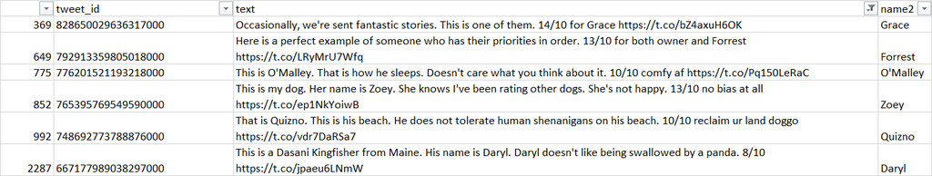

```python
# Import the offline cleaned file.
revised_names=pd.read_csv('revised_names.csv')
revised_names.head(2)
```

|  | ind | tweet_id | in_reply_to_status_id | name2 | text |
| --- | --- | --- | --- | --- | --- |
| 0 | 35 | 8.855190e+17 | NaN | Howard | I have a new hero and his name is Howard. 14/10 https://t.co/gzLHboL7Sk |
| 1 | 72 | 8.786050e+17 | NaN | Martha | Martha is stunning how h*ckin dare you. 13/10 https://t.co/9uABQXgjwa |

```python
# Create lists of new found names and ind = the index of the wrong names df.
new_names1=revised_names['name2'].tolist()
ind_new_names=revised_names['ind'].tolist()
```

```python
# loop through the wrong names df and add the new found names.
i=0
for i in range(len(ind_new_names)):
    wrong_names.loc[ind_new_names[i],'name2']=new_names1[i]
    i=+1
```

```python
# Check if the new names have been added.
wrong_names['name2'].value_counts()
```

```
NoName                                 782
Boomer                                 2
Atlas                                  2
Tickles                                2
Toby                                   2
Bretagne                               2
Cheryl                                 1
Zoe                                    1
Pepe                                   1
Pipsy                                  1
Beebop&Doobert                         1
Cindy                                  1
Zoey                                   1
Charley                                1
BigJumpyRat                            1
Kohl                                   1
Octaviath                              1
Teddy                                  1
Daryl                                  1
Jake                                   1
Oliver                                 1
Bo&Smittens                            1
Teagan                                 1
Airbud                                 1
Cupit&Prencer                          1
Bubka                                  1
Howard                                 1
Charles                                1
Rufus                                  1
Leroi                                  1
                                      ..
Pancho&Peaches                         1
Kip                                    1
Thea                                   1
Quizno                                 1
Grace                                  1
Jack                                   1
Sabertooth                             1
Augie                                  1
Burke&Dexter                           1
Spork                                  1
Loki                                   1
Johm                                   1
Berta                                  1
Zeus                                   1
Klint                                  1
Cletus&Jerome&Alejandro&Burp&Titson    1
Cherokee                               1
Alfredo                                1
Dew                                    1
Hemry                                  1
Guss                                   1
Wylie                                  1
Blue                                   1
Alphred                                1
O'Malley                               1
Reese                                  1
Yoshi                                  1
Martha                                 1
Jessiga                                1
Meeko                                  1
Name: name2, Length: 69, dtype: int64
```

```python
# create lists with all the new names we found (1. by serching for "named " and 2 by manually extractig names in excel)
new_names2=wrong_names['name2'].tolist()
tweet_new_names2=wrong_names['tweet_id'].tolist()
```

```python
# loop through the latest cleaned tweets df and fill in the names we prepared.
i=0
for i in range(len(tweet_new_names2)):
    tweet_clean4.loc[tweet_clean4['tweet_id']==tweet_new_names2[i],'name']=new_names2[i]
    i=+1
```

**Test**

```python
# Check for a tweet that had none as a names....

tweet_clean1.loc[tweet_clean4['text']=="Watch out Airbud. This pupper is also good at the sports. 12/10 I'm thinking D1 https://t.co/1HrFdo7M0C"]['name']
```

```
1811    None
Name: name, dtype: object
```

```python
#..... that the name has been updated in the latest df

tweet_clean4.loc[tweet_clean4['text']=="Watch out Airbud. This pupper is also good at the sports. 12/10 I'm thinking D1 https://t.co/1HrFdo7M0C"]['name']
```

```
1811    Airbud
Name: name, dtype: object
```

```python
# Check overall the count of names of the latest df
tweet_clean4['name'].value_counts()
```

```
NoName       782
Charlie      12
Oliver       12
Lucy         11
Cooper       11
Lola         10
Tucker       10
Penny        10
Bo           9
Toby         9
Winston      9
Sadie        8
Buddy        7
Jack         7
Bailey       7
Daisy        7
Milo         6
Koda         6
Dave         6
Leo          6
Jax          6
Stanley      6
Boomer       6
Scout        6
Oscar        6
Bella        6
Rusty        6
Reggie       5
Alfie        5
Louis        5
            ..
Howard       1
Jazzy        1
Aqua         1
Stefan       1
Gunner       1
Odin         1
Bruno        1
Kathmandu    1
Burt         1
Bubba        1
Gòrdón       1
Meeko        1
Loomis       1
Bobble       1
Brutus       1
Antony       1
Kip          1
Lacy         1
Filup        1
Beebop       1
Kara         1
Clarq        1
Chef         1
Ginger       1
Arlo         1
Cuddles      1
Trip         1
Spanky       1
Humphrey     1
Bert         1
Name: name, Length: 975, dtype: int64
```

```python
# Check the entire list of names - make sure we do not have any "a", "an", etc

tweet_clean4['name'].unique().tolist()
```

```
['Phineas',
 'Tilly',
 'Archie',
 'Darla',
 'Franklin',
 'NoName',
 'Jax',
 'Zoey',
 'Cassie',
 'Koda',
 'Bruno',
 'Ted',
 'Stuart',
 'Oliver',
 'Jim',
 'Zeke',
 'Ralphus',
 'Canela',
 'Gerald',
 'Jeffrey',
 'Maya',
 'Mingus',
 'Derek',
 'Roscoe',
 'Waffles',
 'Jimbo',
 'Maisey',
 'Howard',
 'Lilly',
 'Earl',
 'Lola',
 'Kevin',
 'Yogi',
 'Noah',
 'Bella',
 'Grizzwald',
 'Rusty',
 'Gus',
 'Stanley',
 'Alfy',
```

[output cut: 920 more lines]

```
 'Genevieve',
 'Joshwa',
 'Daryl',
 'Bradlay',
 'Clybe',
 'Keet',
 'Carll',
 'Pepe',
 'Cupit&Prencer',
 'Jockson',
 'Octaviath',
 'Josep',
 'Lugan',
 'Johm',
 'Christoper']
```

```python
tweet_clean5=tweet_clean4[tweet_clean4['in_reply_to_status_id'].isnull()].copy(deep=True)
```

**Test**

```python
tweet_clean5[tweet_clean5['in_reply_to_status_id']>0]
```

|  | tweet_id | in_reply_to_status_id | in_reply_to_user_id | timestamp | source | text | retweeted_status_id | retweeted_status_user_id | retweeted_status_timestamp | expanded_urls | ... | race_confidence | favorite_count | retweet_count | expanded_urls2 | doggo2 | puppo2 | pupper2 | floofer2 | dog_type | wrong_name |
| --- | --- | --- | --- | --- | --- | --- | --- | --- | --- | --- | --- | --- | --- | --- | --- | --- | --- | --- | --- | --- | --- |

0 rows × 28 columns

**Code**

> Remove columns that are not needed.

```python
tweet_clean5.columns.values
```

```
array(['tweet_id', 'in_reply_to_status_id', 'in_reply_to_user_id',
       'timestamp', 'source', 'text', 'retweeted_status_id',
       'retweeted_status_user_id', 'retweeted_status_timestamp',
       'expanded_urls', 'rating_numerator', 'rating_denominator', 'name',
       'doggo', 'floofer', 'pupper', 'puppo', 'dog_race',
       'race_confidence', 'favorite_count', 'retweet_count',
       'expanded_urls2', 'doggo2', 'puppo2', 'pupper2', 'floofer2',
       'dog_type', 'wrong_name'], dtype=object)
```

```python
tweet_clean5.info()
```

```
<class 'pandas.core.frame.DataFrame'>
Int64Index: 2278 entries, 0 to 2355
Data columns (total 28 columns):
tweet_id                      2278 non-null int64
in_reply_to_status_id         0 non-null float64
in_reply_to_user_id           0 non-null float64
timestamp                     2278 non-null datetime64[ns]
source                        2278 non-null object
text                          2278 non-null object
retweeted_status_id           181 non-null float64
retweeted_status_user_id      181 non-null float64
retweeted_status_timestamp    181 non-null object
expanded_urls                 2274 non-null object
rating_numerator              2278 non-null float64
rating_denominator            2278 non-null int64
name                          2278 non-null object
doggo                         2278 non-null object
floofer                       2278 non-null object
pupper                        2278 non-null object
puppo                         2278 non-null object
dog_race                      1731 non-null object
race_confidence               1731 non-null float64
favorite_count                2276 non-null float64
retweet_count                 2276 non-null float64
expanded_urls2                2276 non-null object
doggo2                        2278 non-null object
puppo2                        2278 non-null object
pupper2                       2278 non-null object
floofer2                      2278 non-null object
dog_type                      2278 non-null object
wrong_name                    2278 non-null bool
dtypes: bool(1), datetime64[ns](1), float64(8), int64(2), object(16)
memory usage: 500.5+ KB
```

```python
# drop columns that I will not use.
tweet_clean5.drop(columns=['in_reply_to_status_id', 'in_reply_to_user_id', 'retweeted_status_id',
       'retweeted_status_user_id', 'retweeted_status_timestamp',
       'doggo', 'floofer', 'pupper', 'puppo', 'doggo2', 'puppo2',\
        'pupper2', 'floofer2','expanded_urls2','wrong_name','expanded_urls',], inplace=True)
```

**Test**

```python
tweet_clean5.info()
```

```
<class 'pandas.core.frame.DataFrame'>
Int64Index: 2278 entries, 0 to 2355
Data columns (total 12 columns):
tweet_id              2278 non-null int64
timestamp             2278 non-null datetime64[ns]
source                2278 non-null object
text                  2278 non-null object
rating_numerator      2278 non-null float64
rating_denominator    2278 non-null int64
name                  2278 non-null object
dog_race              1731 non-null object
race_confidence       1731 non-null float64
favorite_count        2276 non-null float64
retweet_count         2276 non-null float64
dog_type              2278 non-null object
dtypes: datetime64[ns](1), float64(4), int64(2), object(5)
memory usage: 231.4+ KB
```

**Code**

> Remove NaN

```python
tweet_clean5.dropna(inplace=True)
```

**Test**

```python
tweet_clean5.info()
```

```
<class 'pandas.core.frame.DataFrame'>
Int64Index: 1730 entries, 1 to 2355
Data columns (total 12 columns):
tweet_id              1730 non-null int64
timestamp             1730 non-null datetime64[ns]
source                1730 non-null object
text                  1730 non-null object
rating_numerator      1730 non-null float64
rating_denominator    1730 non-null int64
name                  1730 non-null object
dog_race              1730 non-null object
race_confidence       1730 non-null float64
favorite_count        1730 non-null float64
retweet_count         1730 non-null float64
dog_type              1730 non-null object
dtypes: datetime64[ns](1), float64(4), int64(2), object(5)
memory usage: 175.7+ KB
```

```python
tweet_clean6=tweet_clean5.copy(deep=True)
```

```python
tweet_clean6['RT']=tweet_clean6['text'].str.contains('RT @')
```

```python
tweet_clean6['RT'].value_counts()
```

```
False    1666
True     64
Name: RT, dtype: int64
```

So there are 64 records that have that flag. Let's see them.

```python
tweet_clean6[tweet_clean6['RT']==True]
```

|  | tweet_id | timestamp | source | text | rating_numerator | rating_denominator | name | dog_race | race_confidence | favorite_count | retweet_count | dog_type | RT |
| --- | --- | --- | --- | --- | --- | --- | --- | --- | --- | --- | --- | --- | --- |
| 36 | 885311592912609280 | 2017-07-13 01:35:06 | <a href="http://twitter.com/download/iphone" rel="nofollow">Twitter for iPhone</a> | RT @dog_rates: This is Lilly. She just parallel barked. Kindly requests a reward now. 13/10 would pet so well https://t.co/SATN4If5H5 | 13.0 | 10 | Lilly | labrador_retriever | 0.908703 | 0.0 | 19297.0 |  | True |
| 78 | 877611172832227328 | 2017-06-21 19:36:23 | <a href="http://twitter.com/download/iphone" rel="nofollow">Twitter for iPhone</a> | RT @rachel2195: @dog_rates the boyfriend and his soaking wet pupper h*cking love his new hat 14/10 https://t.co/dJx4Gzc50G | 14.0 | 10 | NoName | irish_setter | 0.364729 | 0.0 | 83.0 | pupper | True |
| 95 | 873697596434513921 | 2017-06-11 00:25:14 | <a href="http://twitter.com/download/iphone" rel="nofollow">Twitter for iPhone</a> | RT @dog_rates: This is Walter. He won't start hydrotherapy without his favorite floatie. 14/10 keep it pup Walter https://t.co/r28jFx9uyF | 14.0 | 10 | Walter | french_bulldog | 0.099984 | 0.0 | 12518.0 |  | True |
| 130 | 867072653475098625 | 2017-05-23 17:40:04 | <a href="http://twitter.com/download/iphone" rel="nofollow">Twitter for iPhone</a> | RT @rachaeleasler: these @dog_rates hats are 13/10 bean approved https://t.co/nRCdq4g9gG | 13.0 | 10 | NoName | blenheim_spaniel | 0.352946 | 0.0 | 135.0 |  | True |
| 155 | 861769973181624320 | 2017-05-09 02:29:07 | <a href="http://twitter.com/download/iphone" rel="nofollow">Twitter for iPhone</a> | RT @dog_rates: "Good afternoon class today we're going to learn what makes a good boy so good" 13/10 https://t.co/f1h2Fsalv9 | 13.0 | 10 | NoName | cocker_spaniel | 0.046403 | 0.0 | 37911.0 |  | True |
| 211 | 851953902622658560 | 2017-04-12 00:23:33 | <a href="http://twitter.com/download/iphone" rel="nofollow">Twitter for iPhone</a> | RT @dog_rates: This is Astrid. She's a guide doggo in training. 13/10 would follow anywhere https://t.co/xo7FZFIAao | 13.0 | 10 | Astrid | staffordshire_bullterrier | 0.757547 | 0.0 | 10706.0 | doggo | True |
| 260 | 842892208864923648 | 2017-03-18 00:15:37 | <a href="http://twitter.com/download/iphone" rel="nofollow">Twitter for iPhone</a> | RT @dog_rates: This is Stephan. He just wants to help. 13/10 such a good boy https://t.co/DkBYaCAg2d | 13.0 | 10 | Stephan | chihuahua | 0.505370 | 0.0 | 56625.0 |  | True |
| 266 | 841833993020538882 | 2017-03-15 02:10:39 | <a href="http://twitter.com/download/iphone" rel="nofollow">Twitter for iPhone</a> | RT @dog_rates: This is Ken. His cheeks are magic. 13/10 (IG: ken_shiba) https://t.co/btzf1zTDeQ | 13.0 | 10 | Ken | samoyed | 0.201358 | 0.0 | 17504.0 |  | True |
| 341 | 832215726631055365 | 2017-02-16 13:11:05 | <a href="http://twitter.com/download/iphone" rel="nofollow">Twitter for iPhone</a> | RT @dog_rates: This is Moreton. He's the Good Boy Who Lived. 13/10 magical as h*ck https://t.co/rLHGx3VAF3 | 13.0 | 10 | Moreton | afghan_hound | 0.274637 | 0.0 | 10723.0 |  | True |
| 343 | 832040443403784192 | 2017-02-16 01:34:34 | <a href="http://twitter.com/download/iphone" rel="nofollow">Twitter for iPhone</a> | RT @dog_rates: This is Klein. These pics were taken a month apart. He knows he's a stud now. 12/10 total heartthrob https://t.co/guDkLrX8zV | 12.0 | 10 | Klein | miniature_pinscher | 0.796313 | 0.0 | 11131.0 |  | True |
| 359 | 829878982036299777 | 2017-02-10 02:25:42 | <a href="http://twitter.com/download/iphone" rel="nofollow">Twitter for iPhone</a> | RT @dog_rates: This is Loki. He smiles like Elvis. Ain't nothin but a hound doggo. 12/10 https://t.co/QV5nx6otZR | 12.0 | 10 | Loki | golden_retriever | 0.617389 | 0.0 | 5757.0 | doggo | True |
| 411 | 823269594223824897 | 2017-01-22 20:42:21 | <a href="http://twitter.com/download/iphone" rel="nofollow">Twitter for iPhone</a> | RT @dog_rates: We only rate dogs. Please don't send pics of men capturing low level clouds. Thank you... 11/10 https://t.co/rLi83ZyCL5 | 11.0 | 10 | NoName | samoyed | 0.585441 | 0.0 | 11421.0 |  | True |
| 415 | 822647212903690241 | 2017-01-21 03:29:14 | <a href="http://twitter.com/download/iphone" rel="nofollow">Twitter for iPhone</a> | RT @dog_rates: This is Paisley. She really wanted to be president this time. Dreams officially crushed. 13/10 https://t.co/liJGwMp17E | 13.0 | 10 | Paisley | samoyed | 0.416769 | 0.0 | 7390.0 |  | True |
| 422 | 821813639212650496 | 2017-01-18 20:16:54 | <a href="http://twitter.com/download/iphone" rel="nofollow">Twitter for iPhone</a> | RT @dog_rates: Meet Hercules. He can have whatever he wants for the rest of eternity. 12/10 would snug passionately https://t.co/mH0IOyFdIG | 12.0 | 10 | Hercules | saint_bernard | 0.995143 | 0.0 | 3839.0 |  | True |
| 435 | 820446719150292993 | 2017-01-15 01:45:15 | <a href="http://twitter.com/download/iphone" rel="nofollow">Twitter for iPhone</a> | RT @dog_rates: This is Peaches. She's the ultimate selfie sidekick. Super sneaky tongue slip appreciated. 13/10 https://t.co/pbKOesr8Tg | 13.0 | 10 | Peaches | golden_retriever | 0.938048 | 0.0 | 2980.0 |  | True |
| 446 | 819015337530290176 | 2017-01-11 02:57:27 | <a href="http://twitter.com/download/iphone" rel="nofollow">Twitter for iPhone</a> | RT @dog_rates: This is Bo. He was a very good First Doggo. 14/10 would be an absolute honor to pet https://t.co/AdPKrI8BZ1 | 14.0 | 10 | Bo | standard_poodle | 0.351308 | 0.0 | 42228.0 | doggo | True |
| 453 | 818588835076603904 | 2017-01-09 22:42:41 | <a href="http://twitter.com/download/iphone" rel="nofollow">Twitter for iPhone</a> | RT @dog_rates: This is Chelsea. She forgot how to dog. 11/10 get it together pupper https://t.co/nBJ5RE4yHb | 11.0 | 10 | Chelsea | norwegian_elkhound | 0.372202 | 0.0 | 7126.0 | pupper | True |
| 465 | 817181837579653120 | 2017-01-06 01:31:47 | <a href="http://twitter.com/download/iphone" rel="nofollow">Twitter for iPhone</a> | RT @dog_rates: Here's a pupper with squeaky hiccups. Please enjoy. 13/10 https://t.co/MiMKtsLN6k | 13.0 | 10 | NoName | tibetan_mastiff | 0.506312 | 0.0 | 9907.0 | pupper | True |
| 469 | 816829038950027264 | 2017-01-05 02:09:53 | <a href="http://twitter.com/download/iphone" rel="nofollow">Twitter for iPhone</a> | RT @dog_rates: This is Betty. She's assisting with the dishes. Such a good puppo. 12/10 h*ckin helpful af https://t.co/dgvTPZ9tgI | 12.0 | 10 | Betty | golden_retriever | 0.245773 | 0.0 | 5496.0 | puppo | True |
| 476 | 816014286006976512 | 2017-01-02 20:12:21 | <a href="http://twitter.com/download/iphone" rel="nofollow">Twitter for iPhone</a> | RT @dog_rates: This is Larry. He has no self control. Tongue still nifty af tho 11/10 https://t.co/ghyT4Ubk1r | 11.0 | 10 | Larry | english_setter | 0.677408 | 0.0 | 6154.0 |  | True |
| 488 | 813944609378369540 | 2016-12-28 03:08:11 | <a href="http://twitter.com/download/iphone" rel="nofollow">Twitter for iPhone</a> | RT @dog_rates: This is Bruce. He never backs down from a challenge. 11/10 you got this Bruce https://t.co/aI7umZHIq7 | 11.0 | 10 | Bruce | labrador_retriever | 0.427742 | 0.0 | 3732.0 |  | True |
| 522 | 809808892968534016 | 2016-12-16 17:14:20 | <a href="http://twitter.com/download/iphone" rel="nofollow">Twitter for iPhone</a> | RT @dog_rates: This is Maximus. His face is stuck like that. Tragic really. Great tongue tho. 12/10 would pet firmly https://t.co/xIfrsMNLBR | 12.0 | 10 | Maximus | labrador_retriever | 0.861651 | 0.0 | 5711.0 |  | True |
| 530 | 808134635716833280 | 2016-12-12 02:21:26 | <a href="http://twitter.com/download/iphone" rel="nofollow">Twitter for iPhone</a> | RT @dog_rates: This is Milo. I would do terrible things for Milo. 13/10 https://t.co/R6wJyC2Tey | 13.0 | 10 | Milo | cocker_spaniel | 0.740220 | 0.0 | 6961.0 |  | True |
| 535 | 807059379405148160 | 2016-12-09 03:08:45 | <a href="http://twitter.com/download/iphone" rel="nofollow">Twitter for iPhone</a> | RT @dog_rates: This is Cali. She arrived preassembled. Convenient af. 12/10 appears to be rather h*ckin pettable https://t.co/vOBV1ZqVcX | 12.0 | 10 | Cali | golden_retriever | 0.171393 | 0.0 | 8521.0 |  | True |
| 541 | 806242860592926720 | 2016-12-06 21:04:11 | <a href="http://twitter.com/download/iphone" rel="nofollow">Twitter for iPhone</a> | RT @dog_rates: This is Dave. He's currently in a predicament. Doesn't seem to mind tho. 12/10 someone assist Dave https://t.co/nfprKAXqwu | 12.0 | 10 | Dave | cardigan | 0.593858 | 0.0 | 13616.0 |  | True |
| 543 | 805958939288408065 | 2016-12-06 02:15:59 | <a href="http://twitter.com/download/iphone" rel="nofollow">Twitter for iPhone</a> | RT @dog_rates: This is Penny. She fought a bee and the bee won. 10/10 you're fine Penny, everything's fine https://t.co/zrMVdfFej6 | 10.0 | 10 | Penny | irish_setter | 0.574557 | 0.0 | 6238.0 |  | True |
| 552 | 804413760345620481 | 2016-12-01 19:56:00 | <a href="http://twitter.com/download/iphone" rel="nofollow">Twitter for iPhone</a> | RT @dog_rates: This is Rusty. He's going D1 for sure. Insane vertical. 13/10 would draft https://t.co/AsykOwMrXQ | 13.0 | 10 | Rusty | chow | 0.090341 | 0.0 | 3712.0 |  | True |
| 555 | 803692223237865472 | 2016-11-29 20:08:52 | <a href="http://twitter.com/download/iphone" rel="nofollow">Twitter for iPhone</a> | RT @dog_rates: I present to you... Dog Jesus. 13/10 (he could be sitting on a rock but I doubt it) https://t.co/fR1P3g5I6k | 13.0 | 10 | NoName | lakeland_terrier | 0.530104 | 0.0 | 8689.0 |  | True |
| 561 | 802624713319034886 | 2016-11-26 21:26:58 | <a href="http://twitter.com/download/iphone" rel="nofollow">Twitter for iPhone</a> | RT @dog_rates: "Yep... just as I suspected. You're not flossing." 12/10 and 11/10 for the pup not flossing https://t.co/SuXcI9B7pQ | 12.0 | 10 | NoName | cocker_spaniel | 0.253442 | 0.0 | 3403.0 |  | True |
| 566 | 802247111496568832 | 2016-11-25 20:26:31 | <a href="http://twitter.com/download/iphone" rel="nofollow">Twitter for iPhone</a> | RT @dog_rates: Everybody drop what you're doing and look at this dog. 13/10 must be super h*ckin rare https://t.co/I1bJUzUEW5 | 13.0 | 10 | NoName | chihuahua | 0.721188 | 0.0 | 5247.0 |  | True |
| ... | ... | ... | ... | ... | ... | ... | ... | ... | ... | ... | ... | ... | ... |
| 602 | 798644042770751489 | 2016-11-15 21:49:12 | <a href="http://twitter.com/download/iphone" rel="nofollow">Twitter for iPhone</a> | RT @dog_rates: This is Paull. He just stubbed his toe. 10/10 deep breaths Paull https://t.co/J5Mqn8VeYq | 10.0 | 10 | Paull | english_springer | 0.403698 | 0.0 | 2153.0 |  | True |
| 603 | 798628517273620480 | 2016-11-15 20:47:30 | <a href="http://twitter.com/download/iphone" rel="nofollow">Twitter for iPhone</a> | RT @dog_rates: This a Norwegian Pewterschmidt named Tickles. Ears for days. 12/10 I care deeply for Tickles https://t.co/0aDF62KVP7 | 12.0 | 10 | Tickles | beagle | 0.636169 | 0.0 | 2272.0 |  | True |
| 606 | 798340744599797760 | 2016-11-15 01:44:00 | <a href="http://twitter.com/download/iphone" rel="nofollow">Twitter for iPhone</a> | RT @dog_rates: This is Davey. He'll have your daughter home by 8. Just a stand up pup. 11/10 would introduce to mom https://t.co/E6bGWf9EOm | 11.0 | 10 | Davey | papillon | 0.533180 | 0.0 | 3924.0 |  | True |
| 618 | 796177847564038144 | 2016-11-09 02:29:25 | <a href="http://twitter.com/download/iphone" rel="nofollow">Twitter for iPhone</a> | RT @dog_rates: This is Ruby. She just turned on the news. Officially terrified. 11/10 deep breaths Ruby https://t.co/y5KarNXWXt | 11.0 | 10 | Ruby | golden_retriever | 0.600276 | 0.0 | 16628.0 |  | True |
| 627 | 794983741416415232 | 2016-11-05 19:24:28 | <a href="http://twitter.com/download/iphone" rel="nofollow">Twitter for iPhone</a> | RT @dog_rates: This is Rizzy. She smiles a lot. 12/10 contagious af https://t.co/TU4sZogVIq | 12.0 | 10 | Rizzy | schipperke | 0.363272 | 0.0 | 3942.0 |  | True |
| 629 | 794355576146903043 | 2016-11-04 01:48:22 | <a href="http://twitter.com/download/iphone" rel="nofollow">Twitter for iPhone</a> | RT @dog_rates: This is Butter. She can have whatever she wants forever. 12/10 would hug softly https://t.co/x5gXRS1abq | 12.0 | 10 | Butter | cocker_spaniel | 0.500509 | 0.0 | 12014.0 |  | True |
| 634 | 793614319594401792 | 2016-11-02 00:42:53 | <a href="http://twitter.com/download/iphone" rel="nofollow">Twitter for iPhone</a> | RT @dog_rates: When she says you're a good boy and you know you're a good boy because you're a good boy. 13/10 https://t.co/O5IUmRHRIh | 13.0 | 10 | NoName | golden_retriever | 0.705092 | 0.0 | 3661.0 |  | True |
| 661 | 791026214425268224 | 2016-10-25 21:18:40 | <a href="http://twitter.com/download/iphone" rel="nofollow">Twitter for iPhone</a> | RT @dog_rates: This is Alfie. He's touching a butt. Couldn't be happier. 11/10 https://t.co/gx3xF5mZbo | 11.0 | 10 | Alfie | malamute | 0.375098 | 0.0 | 4858.0 |  | True |
| 664 | 790723298204217344 | 2016-10-25 01:14:59 | <a href="http://twitter.com/download/iphone" rel="nofollow">Twitter for iPhone</a> | RT @dog_rates: This is Happy. He's a bathtub reviewer. Seems to be pleased with this one. 12/10 https://t.co/Ln89R4FP7v | 12.0 | 10 | Happy | golden_retriever | 0.078530 | 0.0 | 2704.0 |  | True |
| 686 | 788070120937619456 | 2016-10-17 17:32:13 | <a href="http://twitter.com/download/iphone" rel="nofollow">Twitter for iPhone</a> | RT @dog_rates: This is Bo and Ty. Bo eats paper and Ty felt left out. 11/10 for both https://t.co/1acHQS8rvK | 11.0 | 10 | Bo | golden_retriever | 0.735163 | 0.0 | 3952.0 |  | True |
| 702 | 786036967502913536 | 2016-10-12 02:53:11 | <a href="http://twitter.com/download/iphone" rel="nofollow">Twitter for iPhone</a> | RT @dog_rates: This is Scout. He really wants to kiss himself. H*ckin inappropriate. 11/10 narcissistic af https://t.co/x0gV2Ck3AD | 11.0 | 10 | Scout | golden_retriever | 0.993830 | 0.0 | 8237.0 |  | True |
| 720 | 783347506784731136 | 2016-10-04 16:46:14 | <a href="http://twitter.com/download/iphone" rel="nofollow">Twitter for iPhone</a> | RT @dog_rates: This is Kenny. He just wants to be included in the happenings. 11/10 https://t.co/2S6oye3XqK | 11.0 | 10 | Kenny | cardigan | 0.611525 | 0.0 | 6533.0 |  | True |
| 728 | 782021823840026624 | 2016-10-01 00:58:26 | <a href="http://twitter.com/download/iphone" rel="nofollow">Twitter for iPhone</a> | RT @dog_rates: This is Harper. She scraped her elbow attempting a backflip off a tree. Valiant effort tho. 12/10 https://t.co/oHKJHghrp5 | 12.0 | 10 | Harper | golden_retriever | 0.383223 | 0.0 | 7236.0 |  | True |
| 741 | 780496263422808064 | 2016-09-26 19:56:24 | <a href="http://twitter.com/download/iphone" rel="nofollow">Twitter for iPhone</a> | RT @dog_rates: This is Bell. She likes holding hands. 12/10 would definitely pet with other hand https://t.co/BXIuvkQO9b | 12.0 | 10 | Bell | pug | 0.997310 | 0.0 | 4319.0 |  | True |
| 742 | 780476555013349377 | 2016-09-26 18:38:05 | <a href="http://twitter.com/download/iphone" rel="nofollow">Twitter for iPhone</a> | RT @Patreon: Well. @dog_rates is on Patreon. \n\n12/10. \n\nhttps://t.co/rnKvzt6RJs https://t.co/v4e2ywe8iO | 12.0 | 10 | NoName | pug | 0.919255 | 0.0 | 136.0 |  | True |
| 767 | 777641927919427584 | 2016-09-18 22:54:18 | <a href="http://twitter.com/download/iphone" rel="nofollow">Twitter for iPhone</a> | RT @dog_rates: This is Arnie. He's a Nova Scotian Fridge Floof. Rare af. 12/10 https://t.co/lprdOylVpS | 12.0 | 10 | Arnie | golden_retriever | 0.964929 | 0.0 | 4947.0 |  | True |
| 770 | 776819012571455488 | 2016-09-16 16:24:19 | <a href="http://twitter.com/download/iphone" rel="nofollow">Twitter for iPhone</a> | RT @dog_rates: Everybody look at this beautiful pupper 13/10 https://t.co/hyAC5Hq9GC | 13.0 | 10 | NoName | chihuahua | 0.346545 | 0.0 | 15839.0 | pupper | True |
| 778 | 775898661951791106 | 2016-09-14 03:27:11 | <a href="http://twitter.com/download/iphone" rel="nofollow">Twitter for iPhone</a> | RT @dog_rates: Like father (doggo), like son (pupper). Both 12/10 https://t.co/pG2inLaOda | 12.0 | 10 | NoName | golden_retriever | 0.945523 | 0.0 | 17621.0 | pupperdoggo | True |
| 800 | 772615324260794368 | 2016-09-05 02:00:22 | <a href="http://twitter.com/download/iphone" rel="nofollow">Twitter for iPhone</a> | RT @dog_rates: This is Gromit. He's pupset because there's no need to beware of him. Just wants a pettin. 10/10 https://t.co/eSvz4EapHH | 10.0 | 10 | Gromit | dalmatian | 0.556595 | 0.0 | 3914.0 |  | True |
| 811 | 771171053431250945 | 2016-09-01 02:21:21 | <a href="http://twitter.com/download/iphone" rel="nofollow">Twitter for iPhone</a> | RT @dog_rates: This is Frankie. He's wearing blush. 11/10 really accents the cheek bones https://t.co/iJABMhVidf | 11.0 | 10 | Frankie | samoyed | 0.978833 | 0.0 | 8705.0 |  | True |
| 822 | 770093767776997377 | 2016-08-29 03:00:36 | <a href="http://twitter.com/download/iphone" rel="nofollow">Twitter for iPhone</a> | RT @dog_rates: This is just downright precious af. 12/10 for both pupper and doggo https://t.co/o5J479bZUC | 12.0 | 10 | NoName | golden_retriever | 0.843799 | 0.0 | 3520.0 | pupperdoggo | True |
| 847 | 766078092750233600 | 2016-08-18 01:03:45 | <a href="http://twitter.com/download/iphone" rel="nofollow">Twitter for iPhone</a> | RT @dog_rates: This is Colby. He's currently regretting all those times he shook your hand for an extra treat. 12/10 https://t.co/vtVHtKFtBH | 12.0 | 10 | Colby | toy_poodle | 0.420463 | 0.0 | 2970.0 |  | True |
| 868 | 761750502866649088 | 2016-08-06 02:27:27 | <a href="http://twitter.com/download/iphone" rel="nofollow">Twitter for iPhone</a> | RT @dog_rates: "Tristan do not speak to me with that kind of tone or I will take away the Xbox." 10/10 https://t.co/VGPH0TfESw | 10.0 | 10 | NoName | golden_retriever | 0.586937 | 0.0 | 4535.0 |  | True |
| 890 | 759566828574212096 | 2016-07-31 01:50:18 | <a href="http://twitter.com/download/iphone" rel="nofollow">Twitter for iPhone</a> | RT @dog_rates: This... is a Tyrannosaurus rex. We only rate dogs. Please only send in dogs. Thank you ...10/10 https://t.co/zxw8d5g94P | 10.0 | 10 | NoName | labrador_retriever | 0.967397 | 0.0 | 24319.0 |  | True |
| 895 | 759159934323924993 | 2016-07-29 22:53:27 | <a href="http://twitter.com/download/iphone" rel="nofollow">Twitter for iPhone</a> | RT @dog_rates: AT DAWN...\nWE RIDE\n\n11/10 https://t.co/QnfO7HEQGA | 11.0 | 10 | NoName | irish_terrier | 0.254856 | 0.0 | 1359.0 |  | True |
| 908 | 757729163776290825 | 2016-07-26 00:08:05 | <a href="http://twitter.com/download/iphone" rel="nofollow">Twitter for iPhone</a> | RT @dog_rates: This is Chompsky. He lives up to his name. 11/10 https://t.co/Xl37lQEWd0 | 11.0 | 10 | Chompsky | schipperke | 0.045519 | 0.0 | 9299.0 |  | True |
| 926 | 754874841593970688 | 2016-07-18 03:06:01 | <a href="http://twitter.com/download/iphone" rel="nofollow">Twitter for iPhone</a> | RT @dog_rates: This is Rubio. He has too much skin. 11/10 https://t.co/NLOHmlENag | 11.0 | 10 | Rubio | pug | 0.272205 | 0.0 | 9193.0 |  | True |
| 949 | 752309394570878976 | 2016-07-11 01:11:51 | <a href="http://twitter.com/download/iphone" rel="nofollow">Twitter for iPhone</a> | RT @dog_rates: Everyone needs to watch this. 13/10 https://t.co/Bb3xnpsWBC | 13.0 | 10 | NoName | golden_retriever | 0.181351 | 0.0 | 18963.0 |  | True |
| 1242 | 711998809858043904 | 2016-03-21 19:31:59 | <a href="http://twitter.com/download/iphone" rel="nofollow">Twitter for iPhone</a> | RT @twitter: @dog_rates Awesome Tweet! 12/10. Would Retweet. #LoveTwitter https://t.co/j6FQGhxYuN | 12.0 | 10 | NoName | kuvasz | 0.059895 | 0.0 | 138.0 |  | True |
| 2259 | 667550904950915073 | 2015-11-20 03:51:52 | <a href="http://twitter.com" rel="nofollow">Twitter Web Client</a> | RT @dogratingrating: Exceptional talent. Original humor. Cutting edge, Nova Scotian comedian. 12/10 https://t.co/uarnTjBeVA | 12.0 | 10 | NoName | vizsla | 0.000081 | 0.0 | 37.0 |  | True |

64 rows × 13 columns

```python
#Create a column that flags if a tweet has in the text 'This is Lilly. She just parallel barked. Kindly requests a reward now.'

tweet_clean6['dup']=tweet_clean6['text'].str.contains('This is Lilly. She just parallel barked. Kindly requests a reward now')
```

```python
tweet_clean6[tweet_clean6['dup']==True]
```

|  | tweet_id | timestamp | source | text | rating_numerator | rating_denominator | name | dog_race | race_confidence | favorite_count | retweet_count | dog_type | RT | dup |
| --- | --- | --- | --- | --- | --- | --- | --- | --- | --- | --- | --- | --- | --- | --- |
| 36 | 885311592912609280 | 2017-07-13 01:35:06 | <a href="http://twitter.com/download/iphone" rel="nofollow">Twitter for iPhone</a> | RT @dog_rates: This is Lilly. She just parallel barked. Kindly requests a reward now. 13/10 would pet so well https://t.co/SATN4If5H5 | 13.0 | 10 | Lilly | labrador_retriever | 0.908703 | 0.0 | 19297.0 |  | True | True |
| 356 | 830583320585068544 | 2017-02-12 01:04:29 | <a href="http://twitter.com/download/iphone" rel="nofollow">Twitter for iPhone</a> | This is Lilly. She just parallel barked. Kindly requests a reward now. 13/10 would pet so well https://t.co/SATN4If5H5 | 13.0 | 10 | Lilly | labrador_retriever | 0.908703 | 73397.0 | 19297.0 |  | False | True |

It is clear, we need to drop the rows containing 'RT @'

**Code**

Remove rows that are retweets - containing 'RT @'

```python
# Drop all rows with True on the RT column
tweet_clean7=tweet_clean6[tweet_clean6['RT']==False].copy(deep=True)
```

I will also drop the rows I found as spotted as not quite dog ratings or containing a bunch of dogs.

```python
# then remove the columns RT and dup
tweet_clean7.drop(columns=['RT','dup'], inplace=True)
```

```python
tweet_clean7.drop([315, 516, 695,  433, 902, 1228, 1254, 1274, 1351, 1433, 1635, 1712, 1779, 1843], axis=0, inplace=True)
```

**Test**

```python
tweet_clean7.info()
```

```
<class 'pandas.core.frame.DataFrame'>
Int64Index: 1652 entries, 1 to 2355
Data columns (total 12 columns):
tweet_id              1652 non-null int64
timestamp             1652 non-null datetime64[ns]
source                1652 non-null object
text                  1652 non-null object
rating_numerator      1652 non-null float64
rating_denominator    1652 non-null int64
name                  1652 non-null object
dog_race              1652 non-null object
race_confidence       1652 non-null float64
favorite_count        1652 non-null float64
retweet_count         1652 non-null float64
dog_type              1652 non-null object
dtypes: datetime64[ns](1), float64(4), int64(2), object(5)
memory usage: 167.8+ KB
```

Export the data in order to use it for the analysis.

```python
tweet_clean7.to_csv('twitter_archive_master.csv')
```